# Introducción a Big Data y ML con R

Santiago Bohórquez Correa

9/26/2021

“We are drowning in information and starving for knowledge.” (Rutherford D. Roger)

Big data está en todas partes, y los métodos convencionales de econometría se han quedado corots para trabajar con estos datos. En medicina y computer science se han desarrollado métodos para trabajar con este tipo de datos, y recientemente han sido adoptados en ciencias sociales, desde negocios, economía, finanzas, psicología, etc. El objetivo de esta capacitación es familiarizarse con algunos de estos métodos. Aprenderán técnicas para reducir el número de regresores, contracción de parámetros, y uso de facotres. Estos métodos pueden ser usados para datos transversales, series de tiempo, y panel, al igual que modelos univariados y multivariados.

# Metodología

Esta capacitación es una introducción a métodos de Big Data y Machine Learning, por lo cual partimos del supuesto que no conocen nada de ML. De esta manera, se dará una explicación de los métodos, seguido de un ejemplo práctico sobre como hacerlo en R. Para esto usaremos una base de datos (modificada) de Hipótecas del Distrito de Columbia en EEUU, disponible en: https://www.consumerfinance.gov/data-research/hmda/historic-data/

Estos son los paquetes que necesitaremos usar:

```r
library(tidyverse)
#IC
library(uGMAR)
#stepwise selection
library(RcmdrMisc)
#cross-validation
library(caret)
library(tibble)
library(ggplot2)
library(modelr)
library(dplyr)
library(purrr)
library(tidyr)
library(pryr)
#Ridge
library(glmnet)
#Factores
library(devtools)
#install_github("vqv/ggbiplot")
library(ggbiplot)
library(pls)
#Factores dinamicos
#remotes::install_github("srlanalytics/bdfm")
library(bdfm)
```

### ¿Qué métodos aprenderan en esta capacitación?

- Selección de modelos con criterios de información.
- Métodos de contracción de parámetros
- Métodos de reducción de dimensionalidad (Modelos por factores dinámicos)

### ¿Qué no aprenderan en esta capacitación?

- Métodos de busqueda en texto
- Algunas personas llaman Big Data a muchas observaciones, No vamos a aprender a cargar y manipular grandes bases de datos.
- Nos centraremos en métodos cuyas propiedades estadísticas son más o menos conocidas. Existen muchos más métodos derivados de Computer Science que no alcanzamos a cubrir.

### Libro Base

Estas notas son basadas en:

James, G., Witten, D., Hastie, T., & Tibshirani, R. (2013). An introduction to statistical learning. New York: springer. Disponible en: https://web.stanford.edu/~hastie/ISLR2/ISLRv2_website.pdf

#### Lecturas extras

Si desean complementar lo visto en esta clase pueden revisar la siguiente literatura:

- Hastie, Tibshirani and Friedman (2009), disponible en: http://statweb.stanford.edu/~tibs/ElemStatLearn/
- Hal Varian (review article) http://people.ischool.berkeley.edu/~hal/Papers/2013/ml.pdf
- Bruce Hansen (review article) http://www.ssc.wisc.edu/~bhansen/papers/et_05.html

# Introducción

Tenemos una variable de interes $y$ que queremos predecir y una matriz de regresores $X$, tal que el modelo real es de la forma:

$$y = X\beta + \epsilon$$

donde $\epsilon$ es un termino de innovación y los $\beta$ son parámetros desconocidos.

Para estimar los $\beta$ podemos hacer estimación de mínimos cuadrados, tal que:

$$\underset{\beta}{\min} SSR(\beta) = \underset{\beta}{\min} \left[ T^{-1} \sum_{t=1}^T (y_t - X_t\beta)^2 \right] \\
\hat{\beta}_{MCO} = (X'X)^{-1}X'y$$

### Ejemplo

En esta aplicación queremos estimar la probabilidad que un prestamo para hipoteca sea aceptado. Para esto tenemos datos de la aceptación o rechazo de aplicaciones para hipoteca del Distrito de Columbia en EEUU para el año 2017. Nuestra variable dependiente $y$ será entonces la varaible *loan_granted* que toma el valor de uno (1) si la hipoteca fue otorgada y cero (0) si no lo fue. Y los regresores, $X$, contienen características de las aplicantes, del prestamo pedido, de la casa, y del co-aplicante del prestamo.

Estimamos el modelo completo:

```r
hmdaDC <- read.csv("D:/OneDrive - Universidad EAFIT/EAFIT/Semillero/Capacitaciones/Machine Learning/data_hmdaDC.csv") %>%
        na.omit()

reg1 <- lm(loan_granted ~., data=hmdaDC)

summary(reg1)
```

```
##
## Call:
## lm(formula = loan_granted ~ ., data = hmdaDC)
##
## Residuals:
##     Min      1Q  Median      3Q     Max
## -0.9254 -0.4791  0.2744  0.4489  0.8764
##
## Coefficients: (1 not defined because of singularities)
##                                    Estimate Std. Error t value Pr(>|t|)
## (Intercept)                       5.768e-02  7.242e-02   0.796 0.425792
## loan_type_nameFHA-insured        -7.285e-02  1.164e-02  -6.260 3.92e-10 ***
## loan_type_nameFSA/RHS-guaranteed -1.716e-01  2.803e-01  -0.612 0.540359
## loan_type_nameVA-guaranteed      -2.046e-02  1.586e-02  -1.290 0.196937
## loan_purpose_nameHome purchase    1.630e-01  1.060e-02  15.381  < 2e-16 ***
## loan_purpose_nameRefinancing      4.392e-02  1.045e-02   4.202 2.65e-05 ***
## loan_amount_000s                 -8.790e-07  9.236e-07  -0.952 0.341265
## applicant_income_000s             2.818e-06  2.953e-06   0.954 0.340024
## population                       -1.032e-06  2.825e-06  -0.365 0.714869
## minority_population              -6.211e-04  2.200e-04  -2.823 0.004768 **
## hud_median_family_income                 NA         NA      NA       NA
## tract_to_msamd_income             1.789e-04  1.055e-04   1.695 0.090167 .
## number_of_owner_occupied_units    3.604e-05  1.328e-05   2.713 0.006672 **
## number_of_1_to_4_family_units    -7.373e-06  8.660e-06  -0.851 0.394540
## hispanic_latino                  -3.756e-02  1.373e-02  -2.736 0.006229 **
## co_hispanic_latino                5.879e-03  2.409e-02   0.244 0.807251
## white                             1.165e-01  8.507e-03  13.696  < 2e-16 ***
## co_white                          1.286e-02  1.227e-02   1.048 0.294435
## african_american                  4.815e-02  9.375e-03   5.136 2.83e-07 ***
## co_african_american               2.979e-02  1.728e-02   1.724 0.084759 .
## asian_pacific                     9.579e-02  1.519e-02   6.306 2.91e-10 ***
## co_asian_pacific                  2.114e-02  2.495e-02   0.847 0.396791
## native                           -1.028e-02  3.499e-02  -0.294 0.768836
## co_native                         6.124e-02  9.516e-02   0.644 0.519885
## female                            3.173e-02  6.916e-03   4.588 4.49e-06 ***
## co_female                         4.658e-02  1.205e-02   3.865 0.000112 ***
## same_sex                          3.219e-02  1.850e-02   1.741 0.081779 .
## mixed_race                        4.012e-03  4.608e-02   0.087 0.930615
## family_dwelling                   2.581e-01  6.864e-02   3.761 0.000170 ***
## Owner_occupied                    4.228e-02  8.890e-03   4.756 1.98e-06 ***
## ---
## Signif. codes:  0 '***' 0.001 '**' 0.01 '*' 0.05 '.' 0.1 ' ' 1
##
## Residual standard error: 0.4853 on 27441 degrees of freedom
## Multiple R-squared:  0.0556, Adjusted R-squared:  0.05463
## F-statistic:  57.7 on 28 and 27441 DF,  p-value: < 2.2e-16
```

Si tenemos muchos regresores el vector $\beta$ puedes ser disperso (*sparse*), es decir varios valores son cero. Por lo cual la pregunta que surge es: ¿Debemos usar todos los regresores en $X$? y de no hacerlo, ¿Cómo escogemos cuales dejar y cuales excluir?.

En general, el proceso que usan muchos investigadores consiste en empezar con un modelo sencillo, y se agregan variables ya sea una a una o en pequeños grupos y revisan cuales son significativas, si el p-value es menor a 0.05 por ejemplo, y así escoger cuales dejar en el modelo y cuales eliminar. Esto es conocido como chequeos de robustez de las estimaciones y si se repite este proceso muchas veces esto es conocido como minería de datos (*data-mining*).

Sin embargo, estos métodos presentan el problema que al entrar y sacar variables se cambia la distribución de los otros $\beta$, por lo cual los valores críticos en las estimaciones posteriores deben de ser ajustados o no son validos. Hacer estos ajustes es complejo, y dependiendo de la distribución es posible que no tenga solución analítica!. Por esta razón debemos usar criterios de selección de modelos para escoger el ‘mejor modelo’ y no testeo secuencial basado en p-values.

# Criterios de selección

La forma de escoger el mejor modelo es haciendo uso de los llamados criterios de selección. Para entenderlos primero debemos ver el concepto de divergencia de divergencia de Kullback-Leibler

### Divergencia de Kullback-Leibler (KL)

Como dijimos en la introducción, tratamos de predecir $y$ haciendo uso de un modelo. Es decir estimamos una función $f(y,\beta)$ que se aproxima a la distribución real de los datos $g(y)$. La pregunta es entonces, ¿Qué tan bien se aproxima este $f(y,\beta)$ a $g(y)$? Para esto se usa entonces la divergencia de KL:

$$KL(g; f, \beta) = E_g [\log g(y)] - E_g [\log f(y,\beta)]$$

La anterior definición es haciendo uso de la verosimilitud por facilidad de exposición, pero se puede extender fácilmente bajo ciertas condiciones a MCO, y $E_g$ es la esperanza de la máxima verosimilitud. La intuición de esta medida es que la KL siempre sera postiva, y es más cercana a cero mientras más cercana sea la función $f(y,\beta)$ sea a $g(y)$.

De esta forma, podemos comparar la KL entre diferentes modelos, $f$, para encontrar el mejor modelo. Podemos notar que $E_g [\log g(y)]$ es constante entre estas comparaciones, por lo cual el problema se reduce a comparar entonces las $E_g [\log f(y,\beta)]$ para diferentes $f$. Pero, $E_g [\log f(y,\beta)]$ es desconocida, por lo cual necesitamos una aproximación muestral, $E_{\hat{g}}$, a este valor poblacional, $E_g$:

$$E_{\hat{g}} = T^{-1} \sum_{t=1}^T \log f(y_t,\beta) = T^{-1} \ell_T(\beta)$$

Así para escoger entre dos modelos paramétricos, por ejemplo $f(y,\beta)$ y $h(y,\gamma)$, comparamos la verosimilitud esperada de ambos modelos (o la minima KL, que es equivalente). Es decir, si $E_g [\log f(y,\beta)] > E_g [\log h(y,\gamma)]$, entonces $KL(g; f, \beta) < KL(g; h, \gamma)$ entonces escogemos el modelo $f$ por ser más cercano al real, $g$.

Sin embargo, no conocemos $\beta, \gamma, g$ por lo cual tenemos que estimar los valores $\hat{\beta}$ y $\hat{\gamma}$ que maximizan la verosimilitud y con esto calculamos $E_{\hat{g}}$. Pero, al hacer esto estamos usando la muestra dos veces, primero para estimar los parametros, $\hat{\beta}$ y $\hat{\gamma}$, y luego para estimar $E_{\hat{g}}$, por lo cual tenemos sesgo de muestra para calcular la KL. Además, por definición al calcular el $\hat{\beta}$ este tendrá una verosimilitud mayor que el calculado en $\beta$, ya que este es el que máxima la verosimilitud para la muestra. Lo que implica que sobre-estimamos la Máxima verosimilitud para la muestra comparada con la poblacional.

Este problema es similar a lo que pasa cuando estimamos el $R^2$ de una regresión, por definición este aumenta al aumentar el número de variables, lo mismo pasa con la verosimilitud en la muestra. Por lo cual necesitamos entonces necesitamos castigar por el sesgo de muestra finita para escoger el modelo correcto.

### Criterios de Información de Akaike (AIC) y Takeuchi (TIC)

La idea detrás de los criterios de Información de Akaike (AIC) y Takeuchi (TIC) es estimar este sesgo para penalizar. Como dijimos en la sección anterior, este sesgo proviene (principalmente) de usar la muestra dos veces. Bajo ciertas condiciones de regularidad en las cuales no entraremos en detalle pero que pueden ver en Claeskens and Hjort (2008), el sesgo esperado es:

$$E[Sesgo] = Traza(J^{-1}K)$$

donde $J$ es la matriz de información y $K$ es la varianza del Jacobiano.

#### TIC

Como $E[Sesgo] = Traza(J^{-1}K)$ sustraemos este valor del $E_{\hat{g}} = T^{-1} \sum_{t=1}^T \log f(y_t,\beta)$, asi la KL sería:

$$KL(g; f, \beta) = E_g [\log g(y)] - E_g [\log f(y,\beta)] \\
\approx E_g [\log g(y)] - \left[ \sum_{t=1}^T \log f(y_t,\hat{\beta}) - Traza(J^{-1}K)\right]$$

como $E_g [\log g(y)]$ es desconocido y constante entre modelos, si queremos hacer comparación entre modelos usamos,

$$TIC = - 2T^{-1} \sum_{t=1}^T \log f(y_t,\hat{\beta}) + 2T^{-1} Traza(J^{-1}K)$$

y tomamos el mínimo entre todos los modelos.

#### AIC

Si el modelo esta correctamente especificado, y bajo condiciones de regularidad, la condición de igualdad de la matriz de información se cumple y por lo tanto $J^{-1}=K$. Así, $Traza(J^{-1}K)=Traza(I_p)=p$, donde $p$ es el número de regresores. Usando este valor el AIC es entonces:

$$AIC = - 2T^{-1} \sum_{t=1}^T \log f(y_t,\hat{\beta}) + 2 p T^{-1}$$

y tomamos el mínimo entre todos los modelos.

Noten que el AIC es para modelos correctamente especificados, mientras que el TIC no requiere esto. En este sentido el AIC es un caso especial del TIC. Sin embargo, aun para modelos en los cuales la igualdad de la matriz de información no se cumple el AIC sigue siendo cercano al TIC, ya que el primer termino domina al sesgo. Además, las matrices $J$ y $K$ tienden a ser bastante grandes, hay que estimar $\frac{p(p+1)}{2} +2p$ elementos, lo que implica que estas estimaciones tienen una alta varianza. El AIC tiene mucha menos varianza dado que la corrección del sesgo no depende de los datos. Por lo tanto aun si el modelo esta mal especificado, se debe usar el AIC po encima del TIC, a menos que el tamaño de muestra sea muy grande.

*Nota: Bajo el supuesto que $\epsilon_t|X \sim iid \; N(0,\sigma^2)$ Máxima Verosimilitud y MCO dan los mismo estimadores, por lo cual se pueden usar estos criterios con MCO.*

### Ejemplo

Veamos si la decisión de otorgar o no un prestamo de hipóteca depende más de las caracteristicas del prestamista o de las caracteristicas del prestamos como tal. Comparemos entonces estos dos modelos:

```r
reg2 <- lm(loan_granted ~hispanic_latino +  co_hispanic_latino +    white + co_white  + african_american + co_african_american  + asian_pacific + co_asian_pacific  + native + co_native +  female + co_female + same_sex + mixed_race + applicant_income_000s, data=hmdaDC)

summary(reg2)
```

```
##
## Call:
## lm(formula = loan_granted ~ hispanic_latino + co_hispanic_latino +
##     white + co_white + african_american + co_african_american +
##     asian_pacific + co_asian_pacific + native + co_native + female +
##     co_female + same_sex + mixed_race + applicant_income_000s,
##     data = hmdaDC)
##
## Residuals:
##     Min      1Q  Median      3Q     Max
## -0.7969 -0.4576  0.3327  0.4457  0.6686
##
## Coefficients:
##                         Estimate Std. Error t value Pr(>|t|)
## (Intercept)            4.464e-01  6.057e-03  73.706  < 2e-16 ***
## hispanic_latino       -6.502e-02  1.381e-02  -4.707 2.53e-06 ***
## co_hispanic_latino    -6.547e-03  2.437e-02  -0.269   0.7882
## white                  1.400e-01  8.493e-03  16.479  < 2e-16 ***
## co_white               2.613e-02  1.236e-02   2.113   0.0346 *
## african_american      -2.181e-02  8.938e-03  -2.440   0.0147 *
## co_african_american    2.144e-02  1.746e-02   1.228   0.2194
## asian_pacific          1.198e-01  1.528e-02   7.837 4.77e-15 ***
## co_asian_pacific       3.428e-02  2.522e-02   1.359   0.1742
## native                -5.002e-02  3.534e-02  -1.415   0.1570
## co_native              4.925e-02  9.629e-02   0.512   0.6090
## female                 3.288e-02  6.957e-03   4.726 2.30e-06 ***
## co_female              5.436e-02  1.217e-02   4.466 8.00e-06 ***
## same_sex               3.302e-02  1.870e-02   1.766   0.0774 .
## mixed_race             2.832e-02  4.662e-02   0.608   0.5435
## applicant_income_000s  1.441e-06  2.160e-06   0.667   0.5047
## ---
## Signif. codes:  0 '***' 0.001 '**' 0.01 '*' 0.05 '.' 0.1 ' ' 1
##
## Residual standard error: 0.4913 on 27454 degrees of freedom
## Multiple R-squared:  0.03184,    Adjusted R-squared:  0.03131
## F-statistic:  60.2 on 15 and 27454 DF,  p-value: < 2.2e-16
```

```r
AIC(reg2)
```

```
## [1] 38927.64
```

```r
reg3 <- lm(loan_granted ~ loan_type_name + loan_purpose_name + loan_amount_000s , data=hmdaDC)

summary(reg3)
```

```
##
## Call:
## lm(formula = loan_granted ~ loan_type_name + loan_purpose_name +
##     loan_amount_000s, data = hmdaDC)
##
## Residuals:
##     Min      1Q  Median      3Q     Max
## -0.6185 -0.4734  0.3815  0.4212  0.7064
##
## Coefficients:
##                                    Estimate Std. Error t value Pr(>|t|)
## (Intercept)                       4.077e-01  9.267e-03  43.999  < 2e-16 ***
## loan_type_nameFHA-insured        -1.140e-01  1.124e-02 -10.146  < 2e-16 ***
## loan_type_nameFSA/RHS-guaranteed -1.885e-01  2.838e-01  -0.664   0.5066
## loan_type_nameVA-guaranteed      -3.973e-02  1.586e-02  -2.506   0.0122 *
## loan_purpose_nameHome purchase    2.108e-01  1.017e-02  20.720  < 2e-16 ***
## loan_purpose_nameRefinancing      6.573e-02  1.040e-02   6.321 2.63e-10 ***
## loan_amount_000s                 -9.236e-08  6.765e-07  -0.137   0.8914
## ---
## Signif. codes:  0 '***' 0.001 '**' 0.01 '*' 0.05 '.' 0.1 ' ' 1
##
## Residual standard error: 0.4915 on 27463 degrees of freedom
## Multiple R-squared:  0.03057,    Adjusted R-squared:  0.03036
## F-statistic: 144.4 on 6 and 27463 DF,  p-value: < 2.2e-16
```

```r
AIC(reg3)
```

```
## [1] 38945.57
```

El AIC para el modelo de características de los individuos es 38927.64 mientras que el AIC para el modelo de caracteristicas del prestamo es 38945.57 por lo cual escogeriamos el primer modelo ya que es el de menor AIC.

*Nota: No existe, o al menos desconozco, una función para el calculo de TIC para modelos univariados, por lo cual no se incluye en el ejemplo*

### Otros Criterios de Información

Los dos criterios de información anteriores son basados en la divergencia KL. Pero, existen otros criterios basados en aproximaciones Bayesianes, donde la función de perdida a minimizar es la $Prob(f)$ sea el modelo verdadero. Los más utilizados son:

#### BIC

El criterio de información Bayesiano (BIC) es una aproximación clasica a un procedimiento Bayesiano donde el sesgo proviene de la distribución posterior usando un prior uniforme. El criterio se define como:

$$BIC = - 2T^{-1} \sum_{t=1}^T \log f(y_t,\hat{\beta}) + p \frac{\log T}{T}$$

y tomamos el mínimo entre todos los modelos.

Si comparamos la penalidad del AIC y el BIC es fácil notar que el BIC penaliza más fuerte, ya que $\log T > 2$ para $T \geq 7$ y por lo tanto tiende a escoger modelos con menos variables que el AIC.

#### HQIC

El Hannan–Quinn information criterion (HQIC) al igual que el mBIC es basado en una aproximación Bayesiana, este se define como:

$$HQIC = - 2T^{-1} \sum_{t=1}^T \log f(y_t,\hat{\beta}) + p \frac{\log \log T}{T}$$

y tomamos el mínimo entre todos los modelos.

Como se puede observar, este criterio de información tiene una penalidad que cae entre el AIC y el BIC.

### Ejemplo

Ahora veamos si llegamos a la misma conclusión que habiamos llegado con el AIC al comparar nuestros dos modelos:

```r
BIC(reg2)
```

```
## [1] 39067.39
```

```r
BIC(reg3)
```

```
## [1] 39011.33
```

```r
Time <- reg2$rank+reg2$df.residual
p <- reg2$rank
HQIC <- - 2/Time * as.numeric(logLik(reg2))+ p*log(log(Time))/Time
HQIC
```

```
## [1] 1.417213
```

```r
Time <- reg3$rank+reg3$df.residual
p <- reg3$rank
HQIC <- - 2/Time * as.numeric(logLik(reg3))+ p*log(log(Time))/Time
HQIC
```

```
## [1] 1.417759
```

## Selección con CI

En nuestro ejemplo solo hemos escogido entre dos modelos posibles. Sin embargo, en general tenemos una gran cantidad de posibles regresores y debemos escoger entre todas las posibles combinaciones de estas, por ejemplo en el caso de 10 variables tenemos $2^{10} > 1000$ modelos posibles para estimar y para 20 variables sería $2^{20} > 1.000.000$ modelos posibles. Claramente estimar todos los modelos no es posible, por lo cual necesitamos definir algún método para reducir este número de posibilidades.

### Selección hacia adelante paso a paso.

La selección hacia adelante paso a paso (*Forward stepwise selection*), donde el número máximo de variables es $p_M$, se hace siguiendo los siguientes pasos:

1. Empezamos con un modelo solo con el intercepto ($f_0^*$)
2. Aumentamos el modelo agregandole una variable a la vez, estimamos los $p_M$ modelos y escogemos el mejor modelo con una variable ($f_1^*$) basados en la máxima verosimilitud o MCO.
3. A $f_1^*$ le adicionamos una variable a la vez, estimamos los $p_M - 1$ modelos y escogemos el mejor modelo con una variable ($f_2^*$) basados en la máxima verosimilitud o MCO.
4. Repetimos este proceso agregando de a una variable
5. Estimamos el modelo con todas las variables $f_M^*$ (1 modelo)
6. Escogemos el mejor modelo entre $f_0^*$, $f_1^*$, $f_2^*$, …, $f_M^*$ usando el criterio de información escogido.

Este método usa $1+p_M+(p_M-1)+(p_M-2)+\dots+1) = 1 + \frac{p_M(p_M+1)}{2}$ modelos, así en el caso de 10 variables tenemos que estimar solo 56 modelos y para 20 variables serían 211 modelos.

*Nota: Si no se quieren estimar todos los modelos posibles, una modificación a este procedimiento consiste en calcular el CI en cada paso y parar cuando ya este no mejore*

### Ejemplo

Realicemos entonces la selección hacia adelante para el modelo que predice si la aplicación para hipoteca es aceptada o no. Y comparemos los modelos escogidos por el AIC y el BIC.

```r
stepwise(reg1, trace = FALSE, direction = "forward", criterion = "AIC")
```

```
##
## Direction:  forward
## Criterion:  AIC
```

```
##
## Call:
## lm(formula = loan_granted ~ loan_purpose_name + white + tract_to_msamd_income +
##     asian_pacific + african_american + co_female + loan_type_name +
##     Owner_occupied + female + family_dwelling + minority_population +
##     number_of_owner_occupied_units + hispanic_latino + same_sex +
##     co_african_american, data = hmdaDC)
##
## Coefficients:
##                      (Intercept)    loan_purpose_nameHome purchase
##                        5.434e-02                         1.639e-01
##     loan_purpose_nameRefinancing                             white
##                        4.407e-02                         1.193e-01
##            tract_to_msamd_income                     asian_pacific
##                        1.797e-04                         9.954e-02
##                 african_american                         co_female
##                        4.850e-02                         5.589e-02
##        loan_type_nameFHA-insured  loan_type_nameFSA/RHS-guaranteed
##                       -7.313e-02                        -1.728e-01
##      loan_type_nameVA-guaranteed                    Owner_occupied
##                       -2.064e-02                         4.175e-02
##                           female                   family_dwelling
##                        3.293e-02                         2.591e-01
##              minority_population    number_of_owner_occupied_units
##                       -6.684e-04                         2.787e-05
##                  hispanic_latino                          same_sex
##                       -3.688e-02                         3.968e-02
##              co_african_american
##                        2.333e-02
```

```r
stepwise(reg1, trace = FALSE, direction = "forward")
```

```
##
## Direction:  forward
## Criterion:  BIC
```

```
##
## Call:
## lm(formula = loan_granted ~ loan_purpose_name + white + tract_to_msamd_income +
##     asian_pacific + african_american + co_female + female + loan_type_name +
##     Owner_occupied + family_dwelling, data = hmdaDC)
##
## Coefficients:
##                      (Intercept)    loan_purpose_nameHome purchase
##                       -0.0078631                         0.1670909
##     loan_purpose_nameRefinancing                             white
##                        0.0461816                         0.1192978
##            tract_to_msamd_income                     asian_pacific
##                        0.0005517                         0.1015008
##                 african_american                         co_female
##                        0.0478066                         0.0611419
##                           female         loan_type_nameFHA-insured
##                        0.0325163                        -0.0766913
## loan_type_nameFSA/RHS-guaranteed       loan_type_nameVA-guaranteed
##                       -0.1785777                        -0.0235777
##                   Owner_occupied                   family_dwelling
##                        0.0417852                         0.2596171
```

Podemos observar que el AIC escoge un modelo con muchos más regresores que el BIC, lo cual es de esperarse yaque el BIC penaliza más fuerte el sesgo.

### Selección hacia atras paso a paso.

La selección hacia adelante paso a paso (*Backward stepwise selection*), donde el número máximo de variables es $p_M$, se hace siguiendo los siguientes pasos:

1. Empezamos con el modelo incluyendo todas las variables ($f_M^*$)
2. Disminuimos el modelo quitandole una variable a la vez, estimamos los $p_M$ modelos y escogemos el mejor modelo con $p_M-1$ variables ($f_{M-1}^*$) basados en la máxima verosimilitud o MCO.
3. A $f_{M-1}^*$ le quitamos una variable a la vez, estimamos los $p_M - 1$ modelos y escogemos el mejor modelo con $p_M-2$ variables ($f_{p_M-2}^*$) basados en la máxima verosimilitud o MCO.
4. Repetimos este proceso agregando de a una variable
5. Estimamos el modelo solo con el intercepto $f_0^*$ (1 modelo)
6. Escogemos el mejor modelo entre $f_0^*$, $f_1^*$, $f_2^*$, …, $f_M^*$ usando el criterio de información escogido.

Este método usa $1+p_M+(p_M-1)+(p_M-2)+\dots+1) = 1 + \frac{p_M(p_M+1)}{2}$ modelos, así en el caso de 10 variables tenemos que estimar solo 56 modelos y para 20 variables serían 211 modelos.

*Nota: Si $p_M > N$, es decir si el número de variables es más alto que el número de observaciones esta selección no puede hacerse*

### Ejemplo

Realicemos entonces la selección hacia atrás para el modelo que predice si la aplicación para hipoteca es aceptada o no. Y comparemos los modelos escogidos por el AIC y el BIC haciendo uso de ambos tipos de selección.

```r
stepwise(reg1, trace = FALSE, direction = "backward", criterion = "AIC")
```

```
##
## Direction:  backward
## Criterion:  AIC
```

```
##
## Call:
## lm(formula = loan_granted ~ loan_type_name + loan_purpose_name +
##     minority_population + tract_to_msamd_income + number_of_owner_occupied_units +
##     hispanic_latino + white + african_american + co_african_american +
##     asian_pacific + female + co_female + same_sex + family_dwelling +
##     Owner_occupied, data = hmdaDC)
##
## Coefficients:
##                      (Intercept)         loan_type_nameFHA-insured
##                        5.434e-02                        -7.313e-02
## loan_type_nameFSA/RHS-guaranteed       loan_type_nameVA-guaranteed
##                       -1.728e-01                        -2.064e-02
##   loan_purpose_nameHome purchase      loan_purpose_nameRefinancing
##                        1.639e-01                         4.407e-02
##              minority_population             tract_to_msamd_income
##                       -6.684e-04                         1.797e-04
##   number_of_owner_occupied_units                   hispanic_latino
##                        2.787e-05                        -3.688e-02
##                            white                  african_american
##                        1.193e-01                         4.850e-02
##              co_african_american                     asian_pacific
##                        2.333e-02                         9.954e-02
##                           female                         co_female
##                        3.293e-02                         5.589e-02
##                         same_sex                   family_dwelling
##                        3.968e-02                         2.591e-01
##                   Owner_occupied
##                        4.175e-02
```

```r
stepwise(reg1, trace = FALSE, direction = "backward")
```

```
##
## Direction:  backward
## Criterion:  BIC
```

```
##
## Call:
## lm(formula = loan_granted ~ loan_type_name + loan_purpose_name +
##     minority_population + number_of_owner_occupied_units + white +
##     african_american + asian_pacific + female + co_female + family_dwelling +
##     Owner_occupied, data = hmdaDC)
##
## Coefficients:
##                      (Intercept)         loan_type_nameFHA-insured
##                        8.101e-02                        -7.336e-02
## loan_type_nameFSA/RHS-guaranteed       loan_type_nameVA-guaranteed
##                       -1.709e-01                        -2.151e-02
##   loan_purpose_nameHome purchase      loan_purpose_nameRefinancing
##                        1.654e-01                         4.573e-02
##              minority_population    number_of_owner_occupied_units
##                       -9.691e-04                         3.507e-05
##                            white                  african_american
##                        1.169e-01                         5.352e-02
##                    asian_pacific                            female
##                        9.878e-02                         3.300e-02
##                        co_female                   family_dwelling
##                        6.258e-02                         2.612e-01
##                   Owner_occupied
##                        4.243e-02
```

Vemos que el modelo escogido por el AIC es el mismo, pero el modelo escogido por el BIC cambia. En la selección hacia adelante se escogia la variable *tract_to_msamd_income* que no es escogida la selección hacia atrás. Pero, la selección hacia atrás también selecciona las variables *minority_population* y *number_of_owner_occupied_units*

### Selección hacia adelante y hacia atrás paso a paso

La selección hacia adelante y hacia atrás paso a paso (*Forward/Backward stepwise selection*) se hace el procedimiento hacia adelante, pero al añadir cada variable nueva se realiza la selección hacia atrás en el modelo escogido hasta que no mejora el CI. Y repetimos el proceso hasta llegar a un modelo en el cual no podemos mejorar el CI haciendo selección hacia adelante o hacia atrás.

### Ejemplo

Realicemos este procedimiento con nuestros datos.

```r
stepwise(reg1, trace = FALSE, direction = "forward/backward", criterion = "AIC")
```

```
##
## Direction:  forward/backward
## Criterion:  AIC
```

```
##
## Call:
## lm(formula = loan_granted ~ loan_purpose_name + white + tract_to_msamd_income +
##     asian_pacific + african_american + co_female + loan_type_name +
##     Owner_occupied + female + family_dwelling + minority_population +
##     number_of_owner_occupied_units + hispanic_latino + same_sex +
##     co_african_american, data = hmdaDC)
##
## Coefficients:
##                      (Intercept)    loan_purpose_nameHome purchase
##                        5.434e-02                         1.639e-01
##     loan_purpose_nameRefinancing                             white
##                        4.407e-02                         1.193e-01
##            tract_to_msamd_income                     asian_pacific
##                        1.797e-04                         9.954e-02
##                 african_american                         co_female
##                        4.850e-02                         5.589e-02
##        loan_type_nameFHA-insured  loan_type_nameFSA/RHS-guaranteed
##                       -7.313e-02                        -1.728e-01
##      loan_type_nameVA-guaranteed                    Owner_occupied
##                       -2.064e-02                         4.175e-02
##                           female                   family_dwelling
##                        3.293e-02                         2.591e-01
##              minority_population    number_of_owner_occupied_units
##                       -6.684e-04                         2.787e-05
##                  hispanic_latino                          same_sex
##                       -3.688e-02                         3.968e-02
##              co_african_american
##                        2.333e-02
```

```r
stepwise(reg1, trace = FALSE, direction = "forward/backward")
```

```
##
## Direction:  forward/backward
## Criterion:  BIC
```

```
##
## Call:
## lm(formula = loan_granted ~ loan_purpose_name + white + tract_to_msamd_income +
##     asian_pacific + african_american + co_female + female + loan_type_name +
##     Owner_occupied + family_dwelling, data = hmdaDC)
##
## Coefficients:
##                      (Intercept)    loan_purpose_nameHome purchase
##                       -0.0078631                         0.1670909
##     loan_purpose_nameRefinancing                             white
##                        0.0461816                         0.1192978
##            tract_to_msamd_income                     asian_pacific
##                        0.0005517                         0.1015008
##                 african_american                         co_female
##                        0.0478066                         0.0611419
##                           female         loan_type_nameFHA-insured
##                        0.0325163                        -0.0766913
## loan_type_nameFSA/RHS-guaranteed       loan_type_nameVA-guaranteed
##                       -0.1785777                        -0.0235777
##                   Owner_occupied                   family_dwelling
##                        0.0417852                         0.2596171
```

### Selección hacia atrás y hacia adelante paso a paso

La selección hacia adelante y hacia atrás paso a paso (*Backward/Forward stepwise selection*) se hace el procedimiento hacia atrás, pero al quitar cada variable se realiza la selección hacia adelante en el modelo escogido hasta que no mejora el CI. Y repetimos el proceso hasta llegar a un modelo en el cual no podemos mejorar el CI haciendo selección hacia adelante o hacia atrás.

### Ejemplo

Realicemos este procedimiento con nuestros datos.

```r
stepwise(reg1, trace = FALSE, direction = "backward/forward", criterion = "AIC")
```

```
##
## Direction:  backward/forward
## Criterion:  AIC
```

```
##
## Call:
## lm(formula = loan_granted ~ loan_type_name + loan_purpose_name +
##     minority_population + tract_to_msamd_income + number_of_owner_occupied_units +
##     hispanic_latino + white + african_american + co_african_american +
##     asian_pacific + female + co_female + same_sex + family_dwelling +
##     Owner_occupied, data = hmdaDC)
##
## Coefficients:
##                      (Intercept)         loan_type_nameFHA-insured
##                        5.434e-02                        -7.313e-02
## loan_type_nameFSA/RHS-guaranteed       loan_type_nameVA-guaranteed
##                       -1.728e-01                        -2.064e-02
##   loan_purpose_nameHome purchase      loan_purpose_nameRefinancing
##                        1.639e-01                         4.407e-02
##              minority_population             tract_to_msamd_income
##                       -6.684e-04                         1.797e-04
##   number_of_owner_occupied_units                   hispanic_latino
##                        2.787e-05                        -3.688e-02
##                            white                  african_american
##                        1.193e-01                         4.850e-02
##              co_african_american                     asian_pacific
##                        2.333e-02                         9.954e-02
##                           female                         co_female
##                        3.293e-02                         5.589e-02
##                         same_sex                   family_dwelling
##                        3.968e-02                         2.591e-01
##                   Owner_occupied
##                        4.175e-02
```

```r
stepwise(reg1, trace = FALSE, direction = "backward/forward")
```

```
##
## Direction:  backward/forward
## Criterion:  BIC
```

```
##
## Call:
## lm(formula = loan_granted ~ loan_type_name + loan_purpose_name +
##     minority_population + number_of_owner_occupied_units + white +
##     african_american + asian_pacific + female + co_female + family_dwelling +
##     Owner_occupied, data = hmdaDC)
##
## Coefficients:
##                      (Intercept)         loan_type_nameFHA-insured
##                        8.101e-02                        -7.336e-02
## loan_type_nameFSA/RHS-guaranteed       loan_type_nameVA-guaranteed
##                       -1.709e-01                        -2.151e-02
##   loan_purpose_nameHome purchase      loan_purpose_nameRefinancing
##                        1.654e-01                         4.573e-02
##              minority_population    number_of_owner_occupied_units
##                       -9.691e-04                         3.507e-05
##                            white                  african_american
##                        1.169e-01                         5.352e-02
##                    asian_pacific                            female
##                        9.878e-02                         3.300e-02
##                        co_female                   family_dwelling
##                        6.258e-02                         2.612e-01
##                   Owner_occupied
##                        4.243e-02
```

Es importante anotar que ninguno de estos métodos garantiza encontrar el mejor modelo (de todas las posibles combinaciones), pero algunos criterios si logran encontrarlo si $T \rightarrow \infty$

### Otros métodos

Otra posible solución al problema de usar dos veces los datos es estimar los parámetros, $\beta$, en una muestra distinta a $E_{\hat{g}}$. Entonces dividimos la muestra en dos, una parte para estimación y la otra para evaluar el modelo. Cada observación es usada para estimación y evaluación, y promediamos los resultados. Esto es llamado Validación cruzada.

#### Validación cruzada

Bajo el supuesto de $y_t$ iid, definimos el la validación cruzada dejando uno afuera, CV(1):

Sea $\beta_{ML,-t}$ el estimador de máxima verosimilitud con todas las observaciones menos $t$, estimamos la verosimilitud esperada, $E_{\hat{g}} [\log f(y,\beta)]$ como,

$$CV(1) = T^{-1} \sum_{t=1}^T \log f(y_t,\beta_{ML,-t})$$

La idea es que al $y_t$ ser iid, $\beta_{ML,-t}$ es independiente de $y_t$, así el estimador de la validación cruzada no deberia de tener el problema de sobre ajuste que sucede en la máxima verosimilitud. Calculamos el CV(1) para varios modelos y escogemos el de mayor valor (equivalente al menor KL).

*Nota: Al igual que con los criterios de información podemos hacer selección, hacia atrás, adelante, atrás/adelante, adelante/atrás, para disminuir el número de modelos a estimar*

#### Ejemplo

Hacemos el CV(1) sobre nuestros datos, y con selección hacia adelante vemos cual modelo es escogido.

```r
#Removemos la variable que es perfectamente colineal

hmdaDC1 <- hmdaDC %>%
           select(-hud_median_family_income)

#Ordenamos
hmdaDC1 <- hmdaDC1 %>%
           select(loan_granted, everything())


#Escogemos método de CV
train_control <- trainControl(method = "LOOCV")

#Creamos Dataset de selección
Seleccion <- data.frame(variable=character(),RMSE=double())

p <- length(names(hmdaDC1))
k <- 1
sel <- 1

while (k < p) {

models <- data.frame(model=character(),RMSE=double())
a <- 1
for (i in 2:p) {
       if(i %in% sel) next
      model1 <- train(loan_granted ~., data=hmdaDC1[1:1000, c(sel,i)],
               method = "lm",
               trControl = train_control)
      models[a,1] = names(hmdaDC1)[i]
      models[a,2] = model1$results$RMSE
      a <- a+1
}
minRMSE = which(models$RMSE == min(models$RMSE))
Seleccion[k,1] <- paste("+", models$model[minRMSE])
Seleccion[k,2] <- models$RMSE[minRMSE]
k <- k+1
ind <- which(names(hmdaDC1)==models$model[minRMSE])
sel <- c(sel,ind)
}

Seleccion
```

```
##                            variable      RMSE
## 1               + loan_purpose_name 0.4153916
## 2                      + population 0.4117676
## 3             + minority_population 0.4092449
## 4                  + Owner_occupied 0.4083143
## 5              + co_hispanic_latino 0.4079337
## 6             + co_african_american 0.4077402
## 7           + tract_to_msamd_income 0.4075209
## 8                + loan_amount_000s 0.4074246
## 9                 + family_dwelling 0.4074240
## 10                      + co_native 0.4074266
## 11                     + mixed_race 0.4074340
## 12                          + white 0.4075327
## 13                         + native 0.4076253
## 14                      + co_female 0.4079481
## 15                         + female 0.4082437
## 16                       + co_white 0.4085879
## 17  + number_of_1_to_4_family_units 0.4089529
## 18                + hispanic_latino 0.4093419
## 19                       + same_sex 0.4097373
## 20                  + asian_pacific 0.4101552
## 21               + african_american 0.4105885
## 22               + co_asian_pacific 0.4110225
## 23 + number_of_owner_occupied_units 0.4114722
## 24                 + loan_type_name 0.4120335
## 25          + applicant_income_000s 0.4377447
```

Este método tiene el problema que si $T$ es muy grande tenemos que estimar muchos modelos para obtener esta medida, e.g. usando selección hacia adelante necesitamos estimar $\frac{p(p+1)}{2}*T$ modelos, por lo que el CV(1) tiene un alto costo computacional. Para solucionar esto se usa la validación cruzada $K$-veces:

Dividimos la muestra en $k=1,2,\dots,K$ bloques no traslapados, si los datos son iid estos pueden ser aleatorios, o en el caso de series de tiempo correlacionadas se pueden hacer ordenados. Y obtenemos el estimador,

$$CV(K) = T^{-1} \sum_{k=1}^K \sum_{t \in k} \log f(y_t,\beta_{ML,-k})$$

y escogemos el máximo CV.

*Nota: Un valor bajo de K lleva a modelos sesgados, y un K muy grande implica estimar muchos modelos, en general se usan valores de K entre 5 y 10*

#### Ejemplo

Hacemos el CV(K) sobre nuestros datos para ver cual modelo es escogido.

```r
set.seed(1234)

#Escogemos método de CV
train_control <- trainControl(method = "cv",
                              number = 10)

#Creamos Dataset de selección
Seleccion <- data.frame(variable=character(),RMSE=double())

p <- length(names(hmdaDC1))
k <- 1
sel <- 1

while (k < p) {

models <- data.frame(model=character(),RMSE=double())
a <- 1
for (i in 2:p) {
       if(i %in% sel) next
      model1 <- train(loan_granted ~., data=hmdaDC1[, c(sel,i)],
               method = "lm",
               trControl = train_control)
      models[a,1] = names(hmdaDC1)[i]
      models[a,2] = model1$results$RMSE
      a <- a+1
}
minRMSE = which(models$RMSE == min(models$RMSE))
Seleccion[k,1] <- paste("+", models$model[minRMSE])
Seleccion[k,2] <- models$RMSE[minRMSE]
k <- k+1
ind <- which(names(hmdaDC1)==models$model[minRMSE])
sel <- c(sel,ind)
}

Seleccion
```

```
##                            variable      RMSE
## 1               + loan_purpose_name 0.4924629
## 2                           + white 0.4886964
## 3           + tract_to_msamd_income 0.4875177
## 4                   + asian_pacific 0.4871168
## 5                + african_american 0.4867488
## 6                       + co_female 0.4864625
## 7                  + loan_type_name 0.4861347
## 8                          + female 0.4859270
## 9                  + Owner_occupied 0.4857895
## 10                + family_dwelling 0.4856901
## 11                     + population 0.4856074
## 12                + hispanic_latino 0.4855815
## 13            + minority_population 0.4855195
## 14 + number_of_owner_occupied_units 0.4854916
## 15                       + same_sex 0.4854607
## 16                       + co_white 0.4854446
## 17  + number_of_1_to_4_family_units 0.4854798
## 18            + co_african_american 0.4854264
## 19                         + native 0.4854743
## 20               + loan_amount_000s 0.4854704
## 21               + co_asian_pacific 0.4854834
## 22                      + co_native 0.4855141
## 23             + co_hispanic_latino 0.4855577
## 24                     + mixed_race 0.4855903
## 25          + applicant_income_000s 0.4886779
```

Este método es sensible a la partición en bloques escogida, por lo cual se propone el método de CV(K) repetido, que como su nombre lo indica realiza el procedimineto CV(K) varias veces de forma tal que los bloques escogidos cambian en cada corrida. Esto incrementa el tiempo de estimación porque hay que resestimar en cada repetición.

#### Ejemplo

Hacemos el CV(K) repetido sobre nuestros datos para ver cual modelo es escogido.

```r
set.seed(1234)

#Escogemos método de CV
train_control <- trainControl(method = "repeatedcv",
                              number = 10, repeats = 3)

#Creamos Dataset de selección
Seleccion <- data.frame(variable=character(),RMSE=double())

p <- length(names(hmdaDC1))
k <- 1
sel <- 1

while (k < p) {

models <- data.frame(model=character(),RMSE=double())
a <- 1
for (i in 2:p) {
       if(i %in% sel) next
      model1 <- train(loan_granted ~., data=hmdaDC1[, c(sel,i)],
               method = "lm",
               trControl = train_control)
      models[a,1] = names(hmdaDC1)[i]
      models[a,2] = model1$results$RMSE
      a <- a+1
}
minRMSE = which(models$RMSE == min(models$RMSE))
Seleccion[k,1] <- paste("+", models$model[minRMSE])
Seleccion[k,2] <- models$RMSE[minRMSE]
k <- k+1
ind <- which(names(hmdaDC1)==models$model[minRMSE])
sel <- c(sel,ind)
}

Seleccion
```

```
##                            variable      RMSE
## 1               + loan_purpose_name 0.4924938
## 2                           + white 0.4887185
## 3           + tract_to_msamd_income 0.4874950
## 4                   + asian_pacific 0.4871219
## 5                + african_american 0.4867371
## 6                       + co_female 0.4864550
## 7                  + loan_type_name 0.4861723
## 8                          + female 0.4860009
## 9                  + Owner_occupied 0.4857833
## 10                + family_dwelling 0.4856978
## 11            + minority_population 0.4856284
## 12                + hispanic_latino 0.4855383
## 13 + number_of_owner_occupied_units 0.4855078
## 14            + co_african_american 0.4854702
## 15                       + same_sex 0.4854286
## 16                     + mixed_race 0.4854558
## 17                       + co_white 0.4854786
## 18             + co_hispanic_latino 0.4854520
## 19                         + native 0.4855116
## 20  + number_of_1_to_4_family_units 0.4855431
## 21                     + population 0.4855285
## 22                      + co_native 0.4855582
## 23               + loan_amount_000s 0.4855745
## 24               + co_asian_pacific 0.4855707
## 25          + applicant_income_000s 0.4865460
```

*Nota: En la práctica el CV(K) repetido es el método más usado*

# CI vs Contracción

Con criterios de información para alto número de variables, $p$, el número de variables estimados. $\frac{p(p+1)}{2}$, así para 100 variables tendríamos que estimar 5050 modelos. Por lo cual debemos usar otros métodos.

Hasta ahora nos hemos enfocado en estimación MCO, o Máxima verosimilitud, de los modelos. Sin embargo, la estimación MCO en general tiene bajo sesgo pero alta varianza. Esto puede ser mejorado haciendo algunos de los coeficientes (cercanos a) cero. De esta forma permitimos que haya un poco de sesgo para reducir la varianza de los valores predichos, $\hat{y}_t$, y disminuir el error de predicción esperado. Esto además nos permite tener menos variables con efectos más fuertes. Esto es conocido como contracción de parámetros.

# Contracción (*Shrinkage*)

La poregunta obvia es entonces, ¿Por qué solo concentrarnos en estimadores insesgados? Si nuestro objetivo es la predicción entonces deberiamos tener también en cuenta estimadores sesgados. Para esto vamos a ver algoritmos eficientes que reducen algunos coeficientes a cero (LASSO), o que los contraen a valores cercanos a cero (Ridge), imponiendo penalidades dependiendo del tamaño del coeficiente. Esto es mucho más rápido que estimar $\frac{p(p+1)}{2}$ modelos. Si el modelo es disperso, LASSO es consistente. Ridge es sesgado pero eficiente. Si $p$ es más grande que $T$ LASSO y Ridge funcionan pero los CI no.

## Gauss-Markov vs James-Stein

El teorema de Gauss-Markov dice que el estimador MCO es el MELI, Mejor Estimador Lineal Insesgado, donde mejor implica que es el de menor varianza. Sin embargo, existen otros estimadores que tienen sesgo diferente de cero pero menor varianza por lo cual llevan a un menor error cuadrado medio (esperado) que el estimador MCO. Este hecho era considerado tan contraintuitivo que era concoido como ‘la paradoja de Stein’.

Para escoger entre dos posibles estimadores, decimos que $\hat{\beta}$ domina a $\tilde{\beta}$ si para una medida de riesgo, e.g. Error Cuadrático Medio, $Risk(\hat{\beta}) \leq Risk(\tilde{\beta})$ para todo $\beta$ con desigualdad estricta para al menos un $\beta$. Decimos que $\hat{\beta}$ es admisible con respecto a la función de riesgo, $Risk$, si no existe ningún otro estimador que lo domine.

MCO no es admisible para el Error Cuadrático Medio cuando $p \geq 3$, ya que el estimador de parte positiva de James-Stein lo domina,

$$\hat{\beta}_{JS} = \hat{\beta}_{MCO} \left[ 1 - \frac{(p-2)\hat{\sigma}^2_{MCO}}{\hat{\beta}_{MCO}'\hat{\beta}_{MCO}} \right]_{+}$$

donde $[b]_{+} = \max (b,0)$.

Por lo tanto la contracción puede ser una buena idea.

## Ridge

La regresión Ridge fue diseñada originalmente para resolver problemas de multicolinealidad. Cuando dos regresores están altamente correlacionados, MCO puede producir un estimador grande y positivo para el primero, y uno grande y negativo para el  
segundo, cuando los dos coeficientes reales pueden ser en realidad bastante cercanos a cero.

Ridge soluciona este problema contrayendo los parámetros hacia cero y acercandolos entre ellos. Esta se define como:

$$\hat{\beta}_R = \arg \underset{\beta}{\min} (y - \alpha - X\beta)' (y - \alpha - X\beta) s.a. \beta'\beta \leq a \\
\Leftrightarrow \hat{\beta}_R = \arg \underset{\beta}{\min} \left[ (y - \alpha - X\beta)' (y - \alpha - X\beta) + \lambda \beta'\beta \right]$$

Es fácil probar que existe una relación uno a uno en la muestra entre $\lambda$ y $a$, por lo que no minimizamos esta función con respecto a $\lambda$. $\lambda , a > 0$, y donde $a$ debe ser lo suficientemente pequeña, o tendríamos MCO.

Ahora, si también contraemos $\alpha$, entonces la solución dependera del valor del intercepto $\alpha$, lo cual no es una buena idea. Por lo tanto, debemos centrar las variables $y$ y $X$, De ahora en adelante, trabajaremos entonces con las variables centradas, tal que podemos escribir el problema cómo:

$$\hat{\beta}_R = \arg \underset{\beta}{\min} \left[ (y - X\beta)' (y - X\beta) + \lambda \beta'\beta \right]$$

Entonces,

$$\hat{\beta}_R = (X'X + \lambda I_p)^{-1}X'y$$

$(X'X + \lambda I_p)^{-1}$ siempre es invertible. Esto implica que la regresión Ridge encuentra una solución única aun cuando $p>T$, mientras que MCO es en general no invertible cuando $p>T$ porque el $Rank(X'X) \leq min(T,p)$.

Para entender a que nos referimos con contracción, noten que

$$\hat{\beta}_R = (X'X + \lambda I_p)^{-1}X'y = \sum_{i=1}^p \frac{d_i^2}{d_i^2+\lambda}u_iu_i'y \\
\hat{\beta}_{MCO} = (X'X)^{-1}X'y = \sum_{i=1}^p u_iu_i'y$$

Finalmente, ¿Cómo escogemos el valor de $\lambda$? Lo más usual es utilizar CV, variamos el valor de $\lambda$ y calculamos el CV(K) para cada uno, y esogemos el $\hat{\lambda} = \arg \underset{\lambda}{\min} CV$. Ó para no usar un $\lambda$ muy exigente se usa el $\lambda$ que esta a una desviación standar de este $\arg \underset{\lambda}{\min} CV$

### Ejemplo

Realicemos la regresión Ridge,

```r
#CV(K) para encontrar el lambda

x <- hmdaDC1 %>%
        select(-loan_granted)

x <- data.matrix(x)

y <- as.matrix(hmdaDC1$loan_granted)

cv_model <- cv.glmnet(x, y, alpha = 0)

#lambda que minimiza test MSE
best_lambda <- cv_model$lambda.min
best_lambda
```

```
## [1] 0.08591831
```

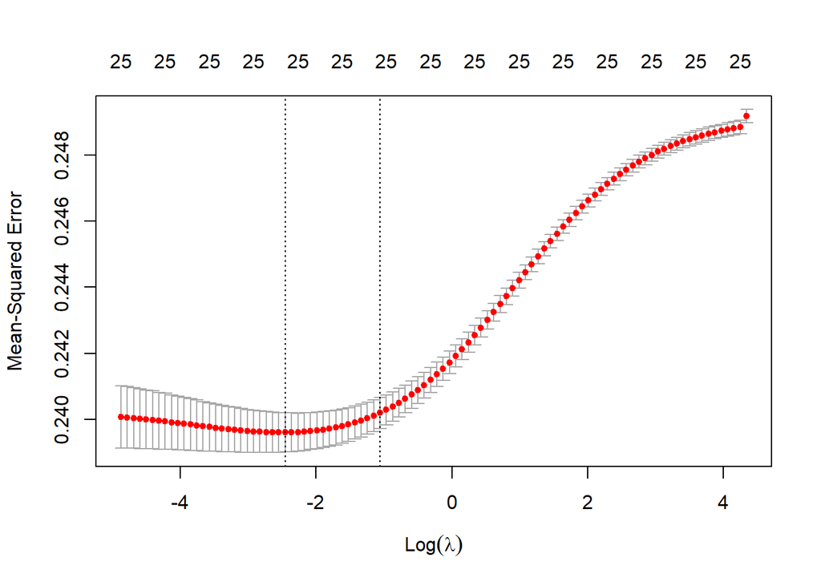

```r
#plot de test MSE por valor de lambda
plot(cv_model)
```

```r
#modelo
best_model <- glmnet(x, y, alpha = 0, lambda = best_lambda)
coef(best_model)
```

```
## 26 x 1 sparse Matrix of class "dgCMatrix"
##                                           s0
## (Intercept)                     1.935217e-01
## loan_type_name                 -9.105806e-03
## loan_purpose_name              -2.380547e-02
## loan_amount_000s               -4.238034e-07
## applicant_income_000s           1.880041e-06
## population                      1.375968e-06
## minority_population            -6.868314e-04
## tract_to_msamd_income           2.005258e-04
## number_of_owner_occupied_units  2.700651e-05
## number_of_1_to_4_family_units  -1.498847e-05
## hispanic_latino                -3.971402e-02
## co_hispanic_latino              2.468843e-04
## white                           9.573276e-02
## co_white                        3.533478e-02
## african_american               -5.683629e-03
## co_african_american             2.998408e-02
## asian_pacific                   7.952182e-02
## co_asian_pacific                4.633463e-02
## native                         -4.904308e-02
## co_native                       6.164597e-02
## female                          2.779689e-02
## co_female                       3.960072e-02
## same_sex                        2.694185e-02
## mixed_race                      1.700969e-02
## family_dwelling                 3.006978e-01
## Owner_occupied                  5.351528e-02
```

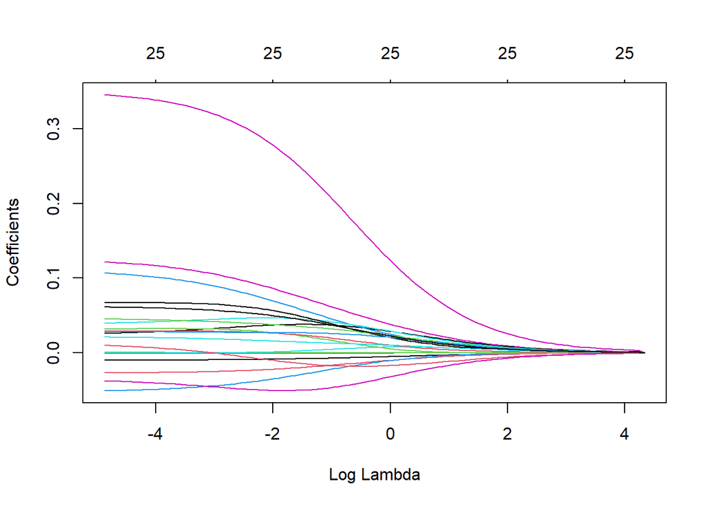

```r
#Ridge trace plot
model <- glmnet(x, y, alpha = 0)
plot(model, xvar = "lambda")
```

## Least Absolute Shrinkage and Selection Operator (LASSO)

Seguimos asumiendo que las variables están centradasm y $||\beta||_p = \left(\sum_{i=1}^p |\beta|^p\right)^{1/p}$.

Ridge soluciona un MC penalizado con $L_2$ como penalidad,

$$\min Q_R = (y -X\beta)'(y -X\beta) + \lambda ||\beta||_2^2$$

Pero, ¿Por qué no escoger otra penalidad?. Tibshirani (1996) propone una penalidad $L_1$,

$$\min Q_R = (y -X\beta)'(y -X\beta) + \lambda ||\beta||_1 \\
\min Q_R = (y -X\beta)'(y -X\beta) + \lambda \sum_{i=1}^p |\beta_i|$$

y puede ser escrito de forma equivalente como,

$$\beta_L = \arg \underset{\beta}{\min} (y - X\beta)' (y - X\beta) \; s.a. \; \sum_{i=1}^p |\beta_i| \leq a$$

Depediente de los datos y relación uno a uno etre $a$ y $\lambda$, donde $a$ es lo suficientemente pequeño. Al igual que Ridge, LASSO evita coeficientes que son demasiado grandes. Pero, a diferencia de Ridge esta penalidad hace que muchos coeficientes sean cero. En general, no existe solución analítica para LASSO.

¿Por qué usamos $L_1$? Tibshirani trato de combinar lo mejor de Ridge y criterios de selección, evitando sus problemas. Los criterios de selección nos dan resultados interpretables. Pero, si $p$ es muy grande es computacionalmente exigente, y si $p>T$ no puede ser usado. Ridge por su parte tiene poca varianza, pero los estimadores son sesgados, y es dificil de interpretar. Así que LASSO selecciona y contrae. Los coeficientes se contraen hacia cero y algunos son exactamente cero. Al mismo tiempo que la complejidad computacional es baja ya que es un problema de optimización convexo. LASSO es un modificación de Least Angle Regression (LARS) que para modelos lineales puede ser estimado fácilmente, aun estimando todos los $\lambda$.

Sin embargo, LASSO también tiene limitaciones. Cuando dos predictores están altamente correlacionado Ridge les asigna coeficientes similares mientras que LASSO le asigna cero a uno de ellos arbitrarimente, y pequeños cambios en la muestra pueden modificar esta elección. Además, cuando el modelo real no es *sparse* LASSO no dara resultados significativos ya que no es ni eficiente, ni consistente.

Finalmente, ¿Cómo escogemos el valor de $\lambda$? Lo más usual es utilizar CV, variamos el valor de $\lambda$ y calculamos el CV(K) para cada uno, y esogemos el $\hat{\lambda} = \arg \underset{\lambda}{\min} CV$. Ó para no usar un $\lambda$ muy exigente se usa el $\lambda$ que esta a una desviación standar de este $\arg \underset{\lambda}{\min} CV$

```r
#CV(K) para encontrar el lambda
cv_model <- cv.glmnet(x, y, alpha = 1)

#lambda que minimiza test MSE
best_lambda <- cv_model$lambda.min
best_lambda
```

```
## [1] 0.002685562
```

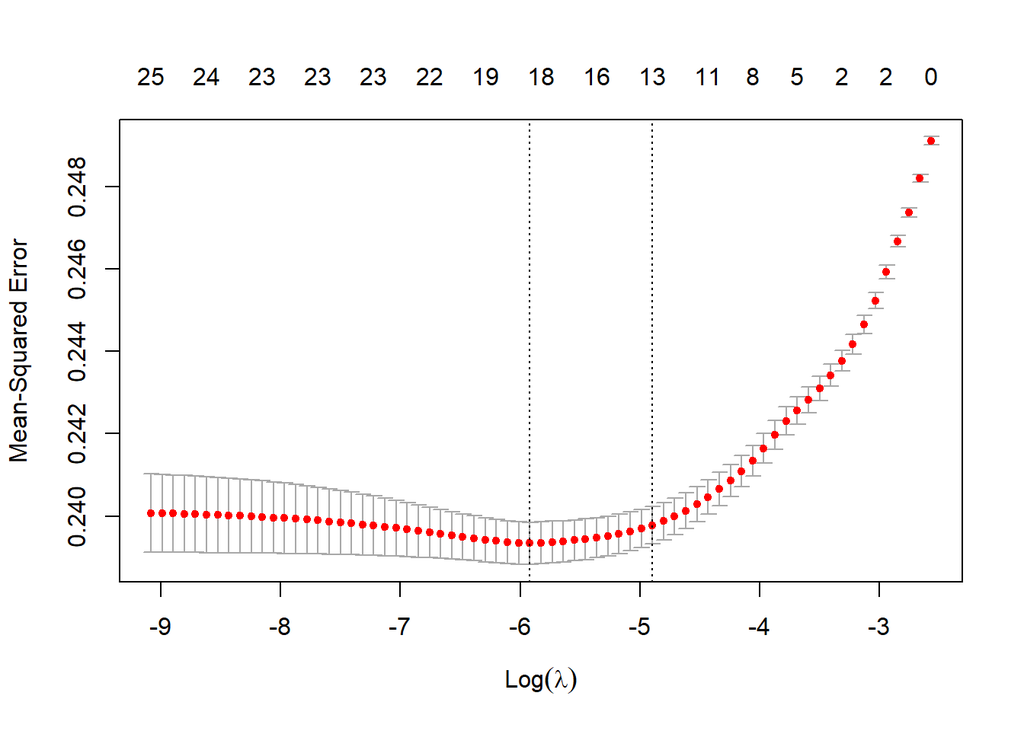

```r
#plot de test MSE por valor de lambda
plot(cv_model)
```

```r
#modelo
best_model <- glmnet(x, y, alpha = 1, lambda = best_lambda)
coef(best_model)
```

```
## 26 x 1 sparse Matrix of class "dgCMatrix"
##                                           s0
## (Intercept)                     2.133513e-01
## loan_type_name                 -6.114785e-03
## loan_purpose_name              -2.361138e-02
## loan_amount_000s                .
## applicant_income_000s           .
## population                      .
## minority_population            -8.763831e-04
## tract_to_msamd_income           1.154879e-04
## number_of_owner_occupied_units  2.170833e-05
## number_of_1_to_4_family_units  -3.621325e-06
## hispanic_latino                -3.899405e-02
## co_hispanic_latino              .
## white                           1.163053e-01
## co_white                        1.965286e-02
## african_american                .
## co_african_american             1.948203e-02
## asian_pacific                   9.607893e-02
## co_asian_pacific                2.211275e-02
## native                         -1.218722e-02
## co_native                       .
## female                          2.559535e-02
## co_female                       4.563426e-02
## same_sex                        2.138045e-02
## mixed_race                      .
## family_dwelling                 2.888189e-01
## Owner_occupied                  5.378720e-02
```

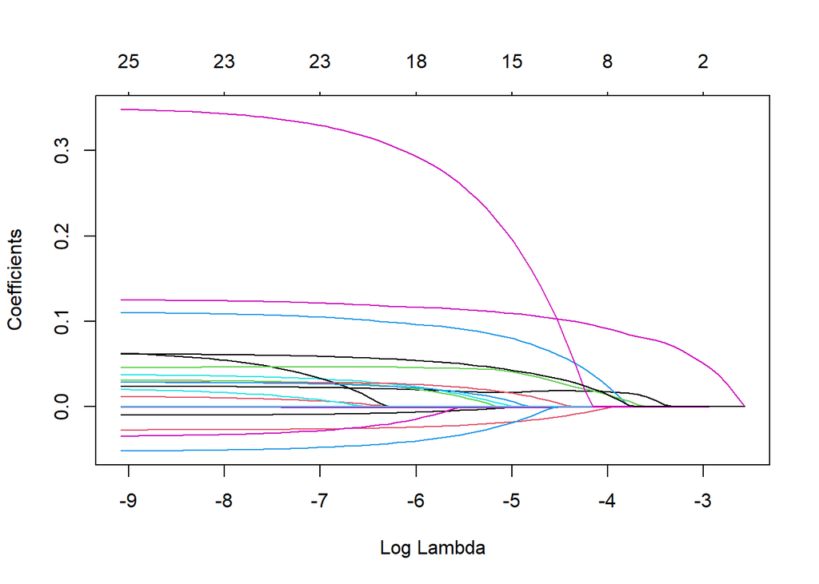

```r
#trace plot
model <- glmnet(x, y, alpha = 1)
plot(model, xvar = "lambda")
```

## Red elastica

Híbrido entre LASSO y Ridge, contrae algunos parámetros e iguala otros a cero. La penalidad se define como,

$$\lambda \left[ \sum_{i=1}^p \left( \gamma |\beta_i| + (1-\gamma) \beta_i^2 \right) \right]$$

Si $\gamma = 1$ tenemos LASSO, si $\gamma = 0$ tenemos Ridge y si $\gamma \in (0,1)$ tenemos una red elástica.

```r
#CV(K) para encontrar el lambda
cv_model <- cv.glmnet(x, y, alpha = 0.5)

#lambda que minimiza test MSE
best_lambda <- cv_model$lambda.min
best_lambda
```

```
## [1] 0.008552349
```

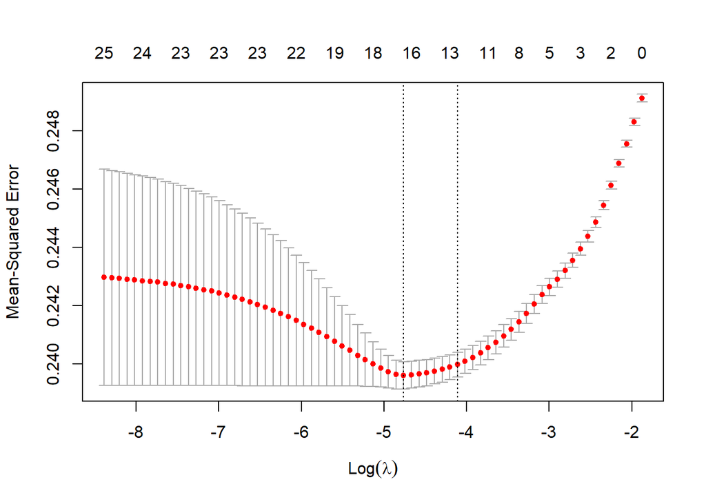

```r
#plot de test MSE por valor de lambda
plot(cv_model)
```

```r
#modelo
best_model <- glmnet(x, y, alpha = 0.5, lambda = best_lambda)
coef(best_model)
```

```
## 26 x 1 sparse Matrix of class "dgCMatrix"
##                                           s0
## (Intercept)                     2.520059e-01
## loan_type_name                 -3.869235e-03
## loan_purpose_name              -2.119149e-02
## loan_amount_000s                .
## applicant_income_000s           .
## population                      .
## minority_population            -8.821785e-04
## tract_to_msamd_income           1.175253e-04
## number_of_owner_occupied_units  1.632329e-05
## number_of_1_to_4_family_units   .
## hispanic_latino                -3.056985e-02
## co_hispanic_latino              .
## white                           1.124821e-01
## co_white                        1.890055e-02
## african_american                .
## co_african_american             9.766283e-03
## asian_pacific                   8.873225e-02
## co_asian_pacific                1.405359e-02
## native                          .
## co_native                       .
## female                          2.170623e-02
## co_female                       4.364858e-02
## same_sex                        1.575841e-02
## mixed_race                      .
## family_dwelling                 2.509195e-01
## Owner_occupied                  4.907751e-02
```

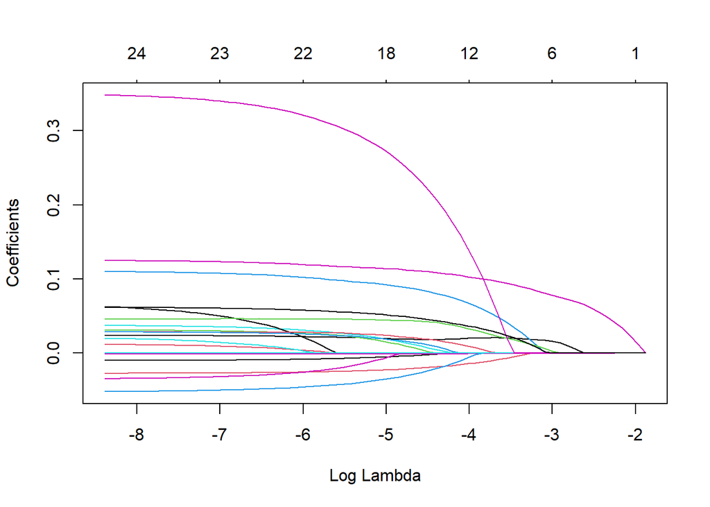

```r
#trace plot
model <- glmnet(x, y, alpha = 0.5)
plot(model, xvar = "lambda")
```

# Análisis Factorial

El análisis factorial difiere de métodos de contracción (o ‘métodos de regresión de alta dimensionalidad’) como LASSO o Ridge porque su intención es distinta. En los métodos de contracción, el supuesto es que si bien tenemos una gran cantidad de variables, $X$, entre las cuales escoger para hacer la predicción, solo un pequeño subgrupo de ellas es necesaria para hacer una predicción de nuestra variable de interes, $y$. Con el análisis factorial suponemos que todas las variables, $X$, tienen una variación común que ayuda con la predicción, de $y$, de forma tal que no escogemos de algunas de ellas, sino que usamos información de ‘todas’ las variables. Escogemos la combinación lineal de las varaibles, o ‘direcciones’, que explican la mayor cantidad de varianza en los datos.

## Análisis Factorial Clásico

Bajo el supuesto que la matriz $X$ con filas $x_t'$, $x_t$ es iid para todo $t$. El análisis factorial clásico especifica una distribución conjunta de $x_t$ y un vector no observable, o ‘latente’, aleatorio de tamaño $k \times 1$, $z_t$.

Con esto especificamos el modelo para $X$:

$$z_t \sim iid \; N_k(0_k,I_k) \\
e_t \sim iid \; N_p(0_p,\Psi) \\
z_t \perp e_t \\
\underset{p\times1}{\underbrace{x_t}} = \underset{p\times1}{\underbrace{\mu}} + \underset{p\times k}{\underbrace{\Lambda}} \underset{k \times 1}{\underbrace{z_t}}+ \underset{p\times 1}{\underbrace{e_t}}$$

donde, $\Lambda$ es una matriz de ‘carga’ de los factores, $\mu$ es un vector de parámetros, $\Psi$ es una matriz diagonal con parámetros $\psi_i$, los elementos de $z_t$ son factores poblacionales con $k < \min(p,T)$. Se busca entonces que $z_t$ explique la estructura de correlación de $x_t$, por esto es que requerimos que $\Psi$ sea diagonal. Los $z_t$ son llamados los factores comunes, y los $e_t$ son los factores idiosincráticos. Bajo este modelo, *condicional* a los factores $z_t$ los elementos de $x_t$ son independientes.

### Problemas de identificación

$\mu$ no presenta problemas ya que podemos trabajar con las series centradas. Si definimos una matriz ortogonal de tamaño $k\times k$, $R$ ( tal que $RR'=R'R=I_k$), y con $\Lambda^*=\Lambda R$ y $z_t^*=R'z_t$ (*recuerden que $z_t$ es no observable!*), entonces

$$x_t = \Lambda z_t + e_t = \Lambda R R' z_t + e_t = \Lambda^*z_t^* + e_t$$

Así que si tratamos de estimar los parámetros haciendo uso de Máxima Verosimilitud obtendremos una solución arbitraria. Ahora, si solo nos interesa tener una buena predicción de $X$ esta falta de identificación no es un problema. Pero, si queremos poder interpretar estas cargas factoriales, $\Lambda$, entonces esto es un problema. Para obtener una solución única necesitamos imponer restricciones sobre la matriz $\Lambda$.

#### ¿Cuantas restricciones debemos imponer?

Necesitamos contar el número de parámetros libres en la matriz de rotación (u ortogonal) $R$:

- La primera columna de $R$ tiene tamaño igual a 1 (por ser ortogonal), así que tiene $k-1$ parámetros libres.
- La segunda columna tiene tamaño igual a 1 y es ortogonal a la primera, así que tenemos $k-2$ parámetros libres.
- La tercera columna tiene $k-3$, etcetera.

### Análisis de componentes principales (PCA)

Una de las formas más populares de imponer estas restricciones es el método de componentes principales. La idea detrás de este método es que cuando tenemos muchas variables en $X$ podemos tomar unas pocas combinaciones lineales de estas variables y usar estas combinaciones lineales como regresores en vez de $X$ para hacer predicción. Estas combinaciones lineales son llamados los componentes principales.

Estos componentes reorientan los datos de forma tal que las primeras dimensiones tienen en cuenta la mayor cantidad de información (*varianza*) posible de las variables $X$. Se extraen entonces los factores como combinaciones lineales o direcciones en los cuales $X$ varia más. Bajo el supuesto que $y$ varia en la misma dimensión que $X$ varia.

#### Ejemplo

Encontremos los componentes principales de nuestra base de datos.

*Nota: Para hacer PCA se deben usar variables continuas centradas y estandarizadas, debido a que dependen de las direcciones de $X$. Por este motivo si la base presenta variables cateogricas estas en general se excluyen ya que el método funciona mejor para variables continuas.*

*Debido a que este es un ejercicio de clase, dejamos las variables cateogricas en nuestra base.*

```r
pca <- prcomp(x, center = TRUE,scale. = TRUE)

summary(pca)
```

```
## Importance of components:
##                           PC1     PC2     PC3    PC4     PC5     PC6     PC7
## Standard deviation     1.8561 1.39358 1.30252 1.2855 1.18497 1.17361 1.06865
## Proportion of Variance 0.1378 0.07768 0.06786 0.0661 0.05617 0.05509 0.04568
## Cumulative Proportion  0.1378 0.21548 0.28335 0.3494 0.40562 0.46071 0.50639
##                            PC8     PC9    PC10    PC11    PC12    PC13    PC14
## Standard deviation     1.06439 1.04110 1.02425 0.99459 0.96133 0.94898 0.93574
## Proportion of Variance 0.04532 0.04336 0.04196 0.03957 0.03697 0.03602 0.03502
## Cumulative Proportion  0.55171 0.59506 0.63703 0.67660 0.71356 0.74958 0.78461
##                           PC15    PC16    PC17    PC18    PC19   PC20    PC21
## Standard deviation     0.91320 0.90404 0.88482 0.83444 0.77821 0.7331 0.55590
## Proportion of Variance 0.03336 0.03269 0.03132 0.02785 0.02422 0.0215 0.01236
## Cumulative Proportion  0.81797 0.85066 0.88198 0.90983 0.93405 0.9556 0.96791
##                          PC22    PC23    PC24    PC25
## Standard deviation     0.5339 0.45338 0.44825 0.33288
## Proportion of Variance 0.0114 0.00822 0.00804 0.00443
## Cumulative Proportion  0.9793 0.98753 0.99557 1.00000
```

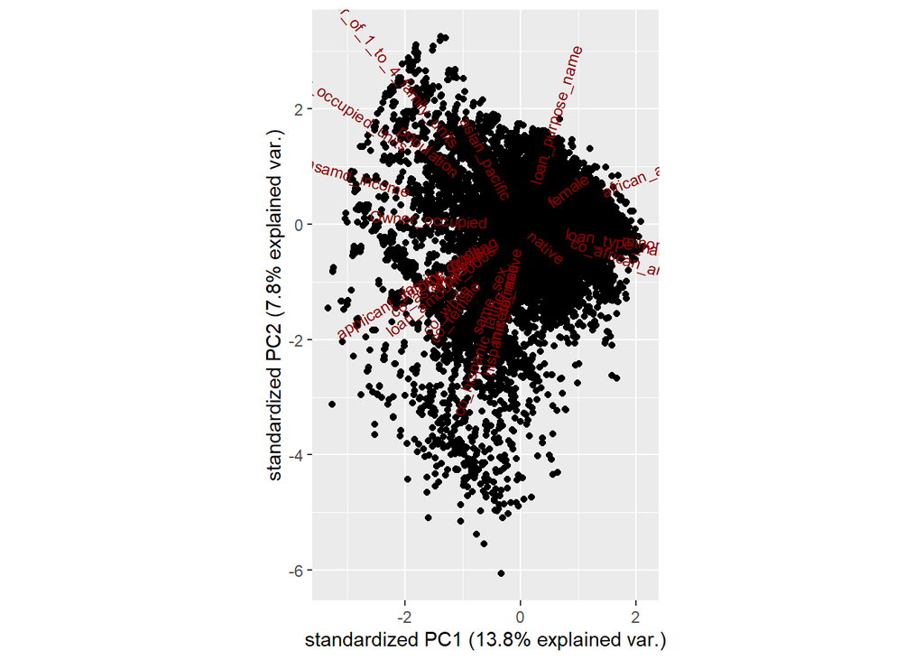

```r
ggbiplot(pca)
```

```r
#reverse the signs
pca$rotation <- -1*pca$rotation

#display principal components
pca$rotation
```

```
##                                        PC1          PC2          PC3
## loan_type_name                 -0.09968409  0.023995825 -0.032215307
## loan_purpose_name              -0.01316039 -0.057568102 -0.066270646
## loan_amount_000s                0.02023846  0.021795937 -0.667587860
## applicant_income_000s           0.03344051  0.026567492 -0.672123020
## population                      0.29983843 -0.325425561 -0.034255523
## minority_population            -0.41512742  0.080349674 -0.068332351
## tract_to_msamd_income           0.42879400 -0.167972930  0.022846913
## number_of_owner_occupied_units  0.39426652 -0.354959275 -0.048151536
## number_of_1_to_4_family_units   0.17784298 -0.293289195 -0.125599109
## hispanic_latino                 0.03536761  0.203993012  0.046390785
## co_hispanic_latino              0.07736610  0.305846648 -0.016029563
## white                           0.30948074  0.297237663  0.081145394
## co_white                        0.27401516  0.405968327 -0.027371531
## african_american               -0.31972869 -0.173742018 -0.133620036
## co_african_american            -0.09303781  0.040052872 -0.160539580
## asian_pacific                   0.01616528 -0.041561754  0.032624354
## co_asian_pacific                0.05466833  0.049658552 -0.009716061
## native                         -0.01398650  0.016043884  0.012752248
## co_native                       0.01016970  0.060255051 -0.008326750
## female                         -0.11133180 -0.109260418  0.024177452
## co_female                       0.20844369  0.359754446 -0.112736788
## same_sex                        0.06861534  0.214232232 -0.058712050
## mixed_race                      0.02891374  0.162832172 -0.016385440
## family_dwelling                 0.02553791  0.019465565 -0.004828362
## Owner_occupied                  0.02488719 -0.002062639  0.029919815
##                                        PC4          PC5          PC6
## loan_type_name                 -0.16005644  0.003835264 -0.119102959
## loan_purpose_name              -0.04575210  0.086129775 -0.077132196
## loan_amount_000s                0.20961885 -0.086953408  0.013255069
## applicant_income_000s           0.19989573 -0.065596198  0.019010482
## population                     -0.20159141 -0.123561012  0.053340293
## minority_population            -0.24419639 -0.084573054 -0.035087873
## tract_to_msamd_income           0.10573573  0.063760220  0.010937202
## number_of_owner_occupied_units -0.21273256 -0.079508519  0.003207704
## number_of_1_to_4_family_units  -0.43291280 -0.101736158 -0.053003437
## hispanic_latino                -0.07295176 -0.471453375  0.138658356
## co_hispanic_latino             -0.22704502 -0.331775150  0.134265061
## white                           0.15237904 -0.113351667 -0.250849636
## co_white                       -0.12698236  0.083706629 -0.194503833
```

[output cut: 179 more lines]

```
## co_hispanic_latino              0.0001507017
## white                          -0.0144429893
## co_white                        0.0016136864
## african_american                0.0566693148
## co_african_american             0.0008769631
## asian_pacific                  -0.0049506349
## co_asian_pacific                0.0066435723
## native                          0.0106089534
## co_native                      -0.0032276914
## female                         -0.0005650426
## co_female                       0.0009582670
## same_sex                       -0.0030124595
## mixed_race                     -0.0043217069
## family_dwelling                 0.0007613743
## Owner_occupied                  0.0078471499
```

Con esto entonces tendríamos 25 componentes principales. Si usamos todos los componentes para hacer una predicción de $y$, entonces no tendríamos ninguna reducción de dimensionalidad y nos encontramos con el mismo problema que antes. Debemos definir cuales factores tomar para nuestra predicción. Existen varios métodos para esto.

#### Elbow plot

Hacemos la gráfica de los valores propios de los componentes principales y miramos cuando se crea un “codo”, es decir, cuando se estabiliza el valor de los componentes, ya que esto indica que estos aportan poco a la varianza explicada.

#### Ejemplo

Miremos como se ve la gráfica de los valores propios.

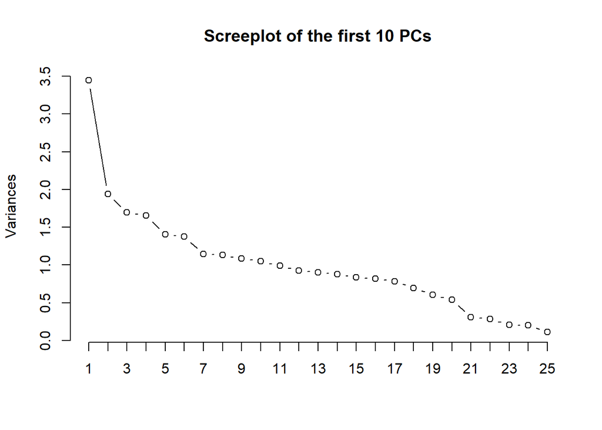

```r
screeplot(pca, type = "l", npcs = 25, main = "Screeplot of the first 10 PCs")
```

El problema que presenta este test gráfico es que es difícil cuantificar exactamente que es poca variación. ¿Dónde deberíamos detenernos? Diferentes personas podrían argumentar que paramos después de 3, 5, 7, o 20 componentes. Por lo cual tests que tengan definiciones más claras son necesarios.

#### Selección valor propio

Este método de selección consiste en seleccionar todos los componentes principales con un valor propio asociado mayor a uno. La idea detrás de esto es que cuando estandarizamos si todas las variables $X$ fueran perfectamente ortogonales entre ellas los valores propios serían todos uno, por lo cual aquellos que sean superiores a uno brindan más información ya que implican que esta dirección es más importante para explicar la varianza de $X$.

#### Ejemplo

Miremos cual sería nuestra selección basados en los valores propios.

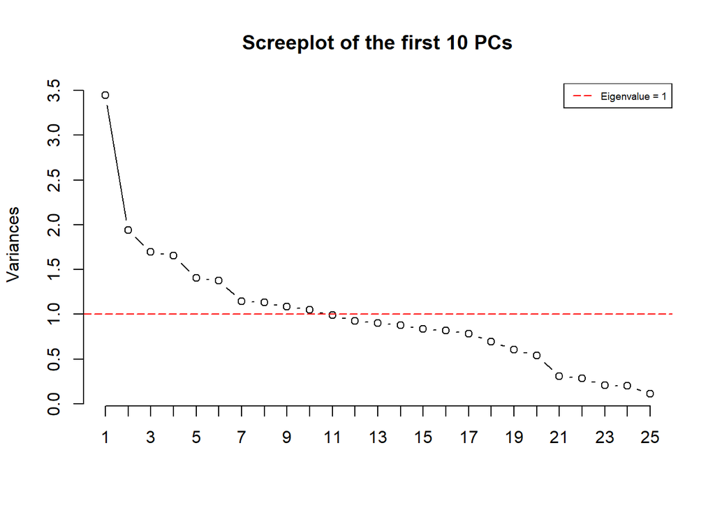

```r
screeplot(pca, type = "l", npcs = 25, main = "Screeplot of the first 10 PCs")
abline(h = 1, col="red", lty=5)
legend("topright", legend=c("Eigenvalue = 1"),
       col=c("red"), lty=5, cex=0.6)
```

Basados en este criterio escogeriamos 10 componentes principales.

#### Varianza explicada

Otra forma de seleccionar el número de componentes principales para predicción es escoger basado en el porcentaje de varianza explicada. En general, se escogen los componentes que expliquen entre 80% y 90% de la varianza.

#### Ejemplo

Miremos cual sería nuestra selección basados en la varianza explicada.

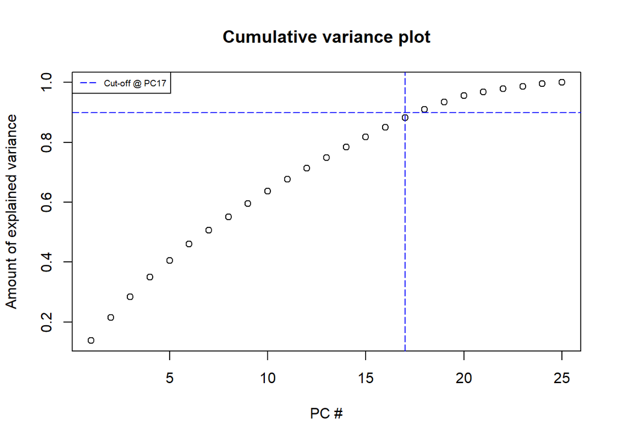

```r
cumpro <- cumsum(pca$sdev^2 / sum(pca$sdev^2))
plot(cumpro[0:25], xlab = "PC #", ylab = "Amount of explained variance", main = "Cumulative variance plot")
abline(v = 17, col="blue", lty=5)
abline(h = 0.9, col="blue", lty=5)
legend("topleft", legend=c("Cut-off @ PC17"),
       col=c("blue"), lty=5, cex=0.6)
```

### Predicción con PCA

Una vez escogemos el número de componentes principales, procedemos a estimar la regresión de $y$ en función de estos componentes.

#### Ejemplo

Miremos nuestro ejemplo utilizando 10 y 17 componentes.

```r
Z = pca$x[,1:10]
pca.lm <- lm(y~Z)
summary(pca.lm)
```

```
##
## Call:
## lm(formula = y ~ Z)
##
## Residuals:
##     Min      1Q  Median      3Q     Max
## -0.9146 -0.4841  0.3009  0.4652  0.7558
##
## Coefficients:
##              Estimate Std. Error t value Pr(>|t|)
## (Intercept)  0.528977   0.002959 178.798  < 2e-16 ***
## ZPC1        -0.041707   0.001594 -26.165  < 2e-16 ***
## ZPC2        -0.019199   0.002123  -9.043  < 2e-16 ***
## ZPC3        -0.004734   0.002271  -2.084  0.03715 *
## ZPC4        -0.009921   0.002301  -4.311 1.63e-05 ***
## ZPC5        -0.007420   0.002497  -2.972  0.00296 **
## ZPC6         0.001506   0.002521   0.598  0.55015
## ZPC7        -0.028609   0.002769 -10.334  < 2e-16 ***
## ZPC8        -0.001167   0.002780  -0.420  0.67473
## ZPC9         0.016217   0.002842   5.707 1.16e-08 ***
## ZPC10       -0.024011   0.002889  -8.313  < 2e-16 ***
## ---
## Signif. codes:  0 '***' 0.001 '**' 0.01 '*' 0.05 '.' 0.1 ' ' 1
##
## Residual standard error: 0.4903 on 27459 degrees of freedom
## Multiple R-squared:  0.03538,    Adjusted R-squared:  0.03503
## F-statistic: 100.7 on 10 and 27459 DF,  p-value: < 2.2e-16
```

```r
Z2 = pca$x[,1:17]
pca.lm2 <- lm(y~Z2)
summary(pca.lm2)
```

```
##
## Call:
## lm(formula = y ~ Z2)
##
## Residuals:
##     Min      1Q  Median      3Q     Max
## -0.8551 -0.4860  0.2897  0.4660  0.9114
##
## Coefficients:
##               Estimate Std. Error t value Pr(>|t|)
## (Intercept)  0.5289771  0.0029547 179.031  < 2e-16 ***
## Z2PC1       -0.0417071  0.0015919 -26.199  < 2e-16 ***
## Z2PC2       -0.0191993  0.0021202  -9.055  < 2e-16 ***
## Z2PC3       -0.0047341  0.0022685  -2.087  0.03690 *
## Z2PC4       -0.0099210  0.0022984  -4.316 1.59e-05 ***
## Z2PC5       -0.0074204  0.0024935  -2.976  0.00292 **
## Z2PC6        0.0015063  0.0025176   0.598  0.54963
## Z2PC7       -0.0286092  0.0027649 -10.347  < 2e-16 ***
## Z2PC8       -0.0011665  0.0027760  -0.420  0.67433
## Z2PC9        0.0162169  0.0028381   5.714 1.11e-08 ***
## Z2PC10      -0.0240110  0.0028848  -8.323  < 2e-16 ***
## Z2PC11      -0.0005720  0.0029708  -0.193  0.84731
## Z2PC12       0.0149927  0.0030736   4.878 1.08e-06 ***
## Z2PC13      -0.0008373  0.0031136  -0.269  0.78799
## Z2PC14      -0.0211516  0.0031576  -6.699 2.15e-11 ***
## Z2PC15       0.0020063  0.0032356   0.620  0.53521
## Z2PC16       0.0079316  0.0032684   2.427  0.01524 *
## Z2PC17       0.0063143  0.0033393   1.891  0.05865 .
## ---
## Signif. codes:  0 '***' 0.001 '**' 0.01 '*' 0.05 '.' 0.1 ' ' 1
##
## Residual standard error: 0.4897 on 27452 degrees of freedom
## Multiple R-squared:  0.03814,    Adjusted R-squared:  0.03754
## F-statistic: 64.02 on 17 and 27452 DF,  p-value: < 2.2e-16
```

Noten que $y$ no esta centrada por lo que obtenemos un estimador del intercepto distinto de cero. Esto nos entrega los coeficientes asociados a los componentes principales, si queremos obtener los coeficientes asociados a los $X$ multiplicamos por los componentes principales.

```r
pca$rotation[,1:10] %*%  coef(pca.lm)[-1] #eliminamos el intercepto
```

```
##                                         [,1]
## loan_type_name                  0.0018679911
## loan_purpose_name               0.0113042586
## loan_amount_000s                0.0003644032
## applicant_income_000s          -0.0002177916
## population                     -0.0014375916
## minority_population             0.0221833976
## tract_to_msamd_income          -0.0196913303
## number_of_owner_occupied_units -0.0075582899
## number_of_1_to_4_family_units   0.0067237880
## hispanic_latino                 0.0048917668
## co_hispanic_latino             -0.0006516549
## white                          -0.0217004238
## co_white                       -0.0226960052
## african_american                0.0149055368
## co_african_american             0.0005945503
## asian_pacific                  -0.0093362965
## co_asian_pacific               -0.0077168587
## native                          0.0067758317
## co_native                       0.0042862918
## female                         -0.0133557610
## co_female                      -0.0113557861
## same_sex                       -0.0233593335
## mixed_race                     -0.0002891246
## family_dwelling                -0.0087994862
## Owner_occupied                 -0.0213428263
```

```r
pca$rotation[,1:17] %*%  coef(pca.lm2)[-1]
```

```
##                                         [,1]
## loan_type_name                  5.047659e-03
## loan_purpose_name               1.847821e-02
## loan_amount_000s               -6.507131e-05
## applicant_income_000s          -2.896050e-04
## population                      2.811243e-04
## minority_population             2.246690e-02
## tract_to_msamd_income          -2.047706e-02
## number_of_owner_occupied_units -6.947289e-03
## number_of_1_to_4_family_units   6.564739e-03
## hispanic_latino                 4.605204e-03
## co_hispanic_latino              1.307644e-03
## white                          -2.738134e-02
## co_white                       -2.353386e-02
## african_american                1.107199e-02
## co_african_american            -3.009426e-03
## asian_pacific                  -6.400752e-03
## co_asian_pacific               -1.328967e-02
## native                          8.678164e-03
## co_native                      -3.226621e-03
## female                         -2.331384e-02
## co_female                      -1.852838e-02
## same_sex                       -4.817992e-03
## mixed_race                      1.976689e-03
## family_dwelling                -1.583478e-02
## Owner_occupied                 -2.041975e-02
```

Esto lo hace R automaticamente si así lo deseamos,

```r
pcr10 <- pcr(loan_granted~ ., 10, # number of components,
                scale=TRUE, data=hmdaDC1)
coef(pcr10)
```

```
## , , 10 comps
##
##                                   loan_granted
## loan_type_nameFHA-insured         2.679835e-03
## loan_type_nameFSA/RHS-guaranteed -1.688029e-03
## loan_type_nameVA-guaranteed      -7.326177e-03
## loan_purpose_nameHome purchase    2.853371e-02
## loan_purpose_nameRefinancing     -2.524633e-02
## loan_amount_000s                 -7.786994e-06
## applicant_income_000s             6.626400e-04
## population                        2.584879e-03
## minority_population              -2.006719e-02
## tract_to_msamd_income             1.766738e-02
## number_of_owner_occupied_units    7.577965e-03
## number_of_1_to_4_family_units    -5.447511e-03
## hispanic_latino                  -6.102081e-03
## co_hispanic_latino                3.595880e-04
## white                             1.828245e-02
## co_white                          1.954082e-02
## african_american                 -1.461436e-02
## co_african_american               1.489584e-03
## asian_pacific                     6.526677e-03
## co_asian_pacific                  5.164041e-03
## native                           -4.448592e-03
## co_native                        -5.239757e-04
## female                            6.980366e-03
## co_female                         1.236796e-02
## same_sex                          1.711957e-02
## mixed_race                       -8.119099e-04
## family_dwelling                   1.100953e-02
## Owner_occupied                    1.632726e-02
```

```r
pcr17 <- pcr(loan_granted~ ., 17, # number of components,
                scale=TRUE, data=hmdaDC1)
coef(pcr17)
```

```
## , , 17 comps
##
##                                   loan_granted
## loan_type_nameFHA-insured        -1.225850e-02
## loan_type_nameFSA/RHS-guaranteed -8.274667e-04
## loan_type_nameVA-guaranteed       2.506663e-03
## loan_purpose_nameHome purchase    3.009163e-02
## loan_purpose_nameRefinancing     -2.793576e-02
## loan_amount_000s                 -4.285781e-05
## applicant_income_000s             5.078059e-04
## population                        1.434548e-03
## minority_population              -1.977733e-02
## tract_to_msamd_income             1.810393e-02
## number_of_owner_occupied_units    7.755147e-03
## number_of_1_to_4_family_units    -4.090384e-03
## hispanic_latino                  -7.716330e-03
## co_hispanic_latino                7.016813e-04
## white                             2.271098e-02
## co_white                          2.349470e-02
## african_american                 -7.458222e-03
## co_african_american               7.064084e-03
## asian_pacific                     8.078226e-03
## co_asian_pacific                  5.840181e-03
## native                           -6.019788e-03
## co_native                         1.643014e-03
## female                            2.654940e-02
## co_female                         1.687181e-02
## same_sex                          3.079292e-03
## mixed_race                       -6.671147e-04
## family_dwelling                   1.524563e-02
## Owner_occupied                    1.133858e-02
```

### PCA con CV

Si bien los métodos anteriores pueden dar una idea sobre cual es el número optimo de componentes principales a usar, podemos hacer uso de lo anteriormente aprendido y usar CV(k) para escoger el número optimo de componentes.

```r
pcr2 <- pcr(loan_granted~ ., 25, # number of components,
                scale=TRUE, data=hmdaDC1, validation='CV')
summary(pcr2)
```

```
## Data:    X dimension: 27470 28
##  Y dimension: 27470 1
## Fit method: svdpc
## Number of components considered: 25
##
## VALIDATION: RMSEP
## Cross-validated using 10 random segments.
##        (Intercept)  1 comps  2 comps  3 comps  4 comps  5 comps  6 comps
## CV          0.4992   0.4915   0.4894   0.4894   0.4894   0.4891    0.489
## adjCV       0.4992   0.4915   0.4894   0.4893   0.4893   0.4891    0.489
##        7 comps  8 comps  9 comps  10 comps  11 comps  12 comps  13 comps
## CV      0.4889   0.4884   0.4884    0.4881     0.488     0.488     0.488
## adjCV   0.4889   0.4884   0.4884    0.4881     0.488     0.488     0.488
##        14 comps  15 comps  16 comps  17 comps  18 comps  19 comps  20 comps
## CV       0.4879    0.4878    0.4872    0.4872    0.4872    0.4871    0.4871
## adjCV    0.4879    0.4878    0.4872    0.4872    0.4871    0.4871    0.4871
##        21 comps  22 comps  23 comps  24 comps  25 comps
## CV       0.4871    0.4871    0.4872    0.4867    0.4866
## adjCV    0.4871    0.4871    0.4872    0.4866    0.4866
##
## TRAINING: % variance explained
##               1 comps  2 comps  3 comps  4 comps  5 comps  6 comps  7 comps
## X              12.790     20.4   26.866   32.891   38.323   43.348   48.251
## loan_granted    3.091      3.9    3.941    3.943    4.069    4.093    4.132
##               8 comps  9 comps  10 comps  11 comps  12 comps  13 comps
## X              52.354   56.170    59.893    63.535    67.102    70.589
## loan_granted    4.334    4.337     4.481     4.532     4.543     4.544
##               14 comps  15 comps  16 comps  17 comps  18 comps  19 comps
## X                73.93    77.163    80.277    83.240    86.163    88.879
## loan_granted      4.59     4.612     4.862     4.881     4.903     4.916
##               20 comps  21 comps  22 comps  23 comps  24 comps  25 comps
## X               91.345    93.492    95.415    96.519    97.538    98.273
## loan_granted     4.923     4.939     4.939     4.939     5.122     5.139
```

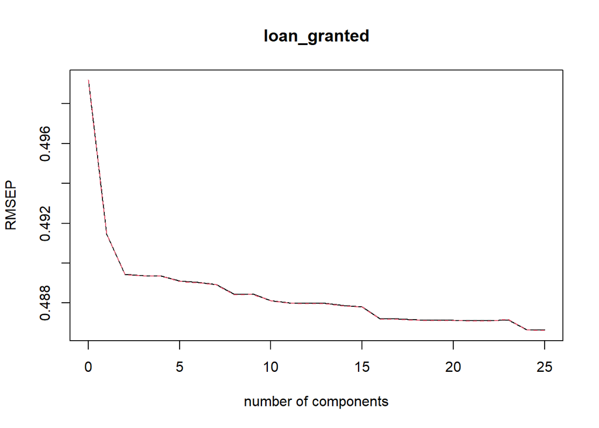

```r
#visualize cross-validation plots
validationplot(pcr2)
```

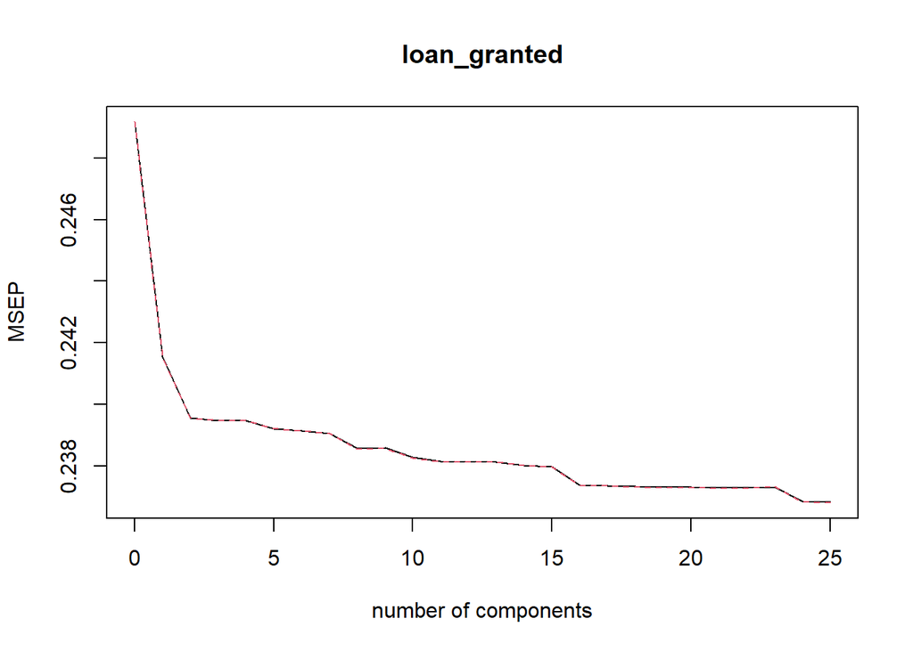

```r
validationplot(pcr2, val.type="MSEP")
```

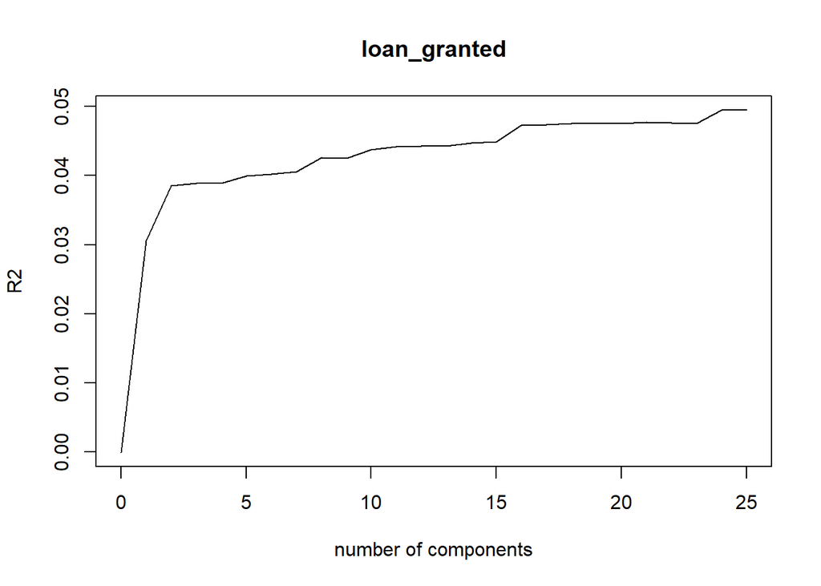

```r
validationplot(pcr2, val.type="R2")
```

Bajo todos los test el mejor modelo incluye todos los 25 componentes.

## Factores Dinamicos

*Nota: Esta sección esta basada en: Stock, James H., and Mark W. Watson. “Forecasting using principal components from a large number of predictors.” Journal of the American statistical association 97, no. 460 (2002): 1167-1179.*

El análisis factorial tambien puede ser realizado para hacer predicciones de series de tiempo. Con este objetivo en mente Stock y Watson (2002) propusieron el modelo de factores dinámicos. Miremos el modelo para un paso adelante con $k$ factores.

$$y_{t+1} = \gamma(L)y_t + \beta(L)f_t +\epsilon_{t+1} \\
x_{it} = \lambda_i(L) f_t + e_{it}$$

donde asumimos que $E(\epsilon_{t+1} | \Omega_t) = 0$, y $ _t$ es todo el conjunto de información disponible en $t$. $\gamma(L), \beta(L),\lambda_i(L)$ son rezagos polinomiales. Suponiendo que todos los polinomios tienen máximo $q$ rezagos, definimos $F_t = vec(f_t,f_{t-1},\dots,f_{t-q})$, podemos reescribir el modelo como,

$$y_{t+1} = \gamma(L)y_t + \beta(L)f_t +\epsilon_{t+1} \\
X_{t} = \Lambda F_t + e_{t}$$

Ahora, si queremos hacer predicción para varios periodos hacia adelante Stock and Watson (2002) proponen el siguiente modelo,

$$y_{t+h} = \gamma_h(L)y_t + \beta_h(L)F_t +\epsilon^h_{t+h}$$

### Procedimiento

1. Preprocesamiento de datos:
1. Volvemos todas las series estacionarias
2. Centramos y estandarizamos las variables
3. Removemos outliers (datos a más de 10 veces el rango intercuartilico de la mediana)
4. Opcionalmente aumentar $X_t$ con rezagos
2. Estimar los factores (e.g. hacer PCA)
3. Estimar la regresión de predicción

#### Ejemplo

Estimamos los factores dinámicos para una serie de tiempo de muertes por enfermedades pulmonares en UK.

```r
dta <- cbind(fdeaths, mdeaths)

m0 <- dfm(dta, forecast = 2) # estimation with 2 period forecast
```

```r
predict(m0)                  # series with imputations and forecasts
```

```
##            fdeaths   mdeaths
## Jan 1974  858.4972 2221.6695
## Feb 1974  702.6411 1841.8766
## Mar 1974  769.5864 2005.0102
## Apr 1974  696.2785 1826.3719
## May 1974  541.3216 1448.7701
## Jun 1974  434.5393 1188.5611
## Jul 1974  456.0003 1240.8576
## Aug 1974  402.9463 1111.5746
## Sep 1974  416.9709 1145.7501
## Oct 1974  568.9937 1516.2020
## Nov 1974  595.8888 1581.7407
## Dec 1974  685.7797 1800.7883
## Jan 1975  817.7783 2122.4451
## Feb 1975  788.6731 2051.5209
## Mar 1975  806.1804 2094.1830
## Apr 1975  680.9794 1789.0910
## May 1975  496.7806 1340.2319
## Jun 1975  457.1155 1243.5752
## Jul 1975  427.5856 1171.6161
## Aug 1975  411.6309 1132.7374
## Sep 1975  363.0681 1014.3988
## Oct 1975  470.0324 1275.0514
## Nov 1975  557.7224 1488.7361
## Dec 1975  780.2686 2031.0407
## Jan 1976  774.9082 2017.9783
## Feb 1976 1101.3264 2813.4003
## Mar 1976  888.0579 2293.7037
## Apr 1976  545.6491 1459.3156
## May 1976  441.7974 1206.2478
## Jun 1976  421.4194 1156.5903
## Jul 1976  389.8685 1079.7065
## Aug 1976  338.4841  954.4919
## Sep 1976  357.7784 1001.5088
## Oct 1976  444.0418 1211.7169
## Nov 1976  548.7833 1466.9529
## Dec 1976  776.2949 2021.3575
## Jan 1977  860.4408 2226.4058
## Feb 1977  640.9290 1691.4953
## Mar 1977  657.9442 1732.9583
```

[output cut: 20 more lines]

```
## Dec 1978  683.5061 1795.2481
## Jan 1979  845.3990 2189.7517
## Feb 1979  739.4752 1931.6346
## Mar 1979  714.3322 1870.3657
## Apr 1979  593.1582 1575.0866
## May 1979  462.4111 1256.4797
## Jun 1979  408.7358 1125.6826
## Jul 1979  392.4037 1085.8842
## Aug 1979  363.2207 1014.7707
## Sep 1979  362.9584 1014.1315
## Oct 1979  401.1668 1107.2384
## Nov 1979  482.0947 1304.4449
## Dec 1979  534.5545 1432.2800
## Jan 1980  540.7868 1447.4669
## Feb 1980  545.5324 1459.0310
```

```r
summary(m0)                  # summary of the model
```

```
##
## Call:
## dfm(data = dta, forecasts = 2)
##
## Bayesian dynamic factor model with 1 factor(s) and 1 lag(s)
##
## Observation Equation:
##         Sample Fit Load (1)
## fdeaths     0.9888    0.703
## mdeaths     0.9888    0.711
##
## Log Likelihood: -605.822  BIC: 1251.403
```

```r
factors(m0)                  # estimated factor
```

```
##              Jan         Feb         Mar         Apr         May         Jun
## 1974  235.561782  112.285477  165.236736  107.252859  -15.312240  -99.773012
## 1975  203.354695  180.333545  194.181178   95.151916  -50.542436  -81.916068
## 1976  169.446029  427.630599  258.943239  -11.889300  -94.032096 -110.150356
## 1977  237.099125   63.473494   76.931888   80.597094  -62.993835 -120.078468
## 1978  177.075710  241.648640  141.408933  -16.212165  -37.974000  -95.081296
## 1979  225.201635  141.419862  121.532700   25.688618  -77.727438 -120.182624
## 1980  -15.735237  -11.981659
##              Jul         Aug         Sep         Oct         Nov         Dec
## 1974  -82.798186 -124.761900 -113.668957    6.575355   27.848436   98.948710
## 1975 -105.273158 -117.892720 -156.304011  -71.699259   -2.339757  173.685907
## 1976 -135.105918 -175.749104 -160.487969  -92.256897   -9.410321  170.542852
## 1977 -125.887759 -161.817128 -155.628140 -120.743939 -100.721672   55.892820
## 1978 -116.175584 -157.796601 -153.700363 -109.964914 -113.948046   97.150420
## 1979 -133.100702 -156.183318 -156.390786 -126.169377  -62.158497  -20.664726
## 1980
```